# Bayesian statistics and modelling | Nature Reviews Methods Primers

# Bayesian statistics and modelling

- [Rens van de Schoot](https://www.nature.com/articles/s43586-020-00001-2?fbclid=IwAR0vm-qDeW_4LiBWon6g12OmD_V6zZjy5qjfGNNOTLeeeelQgi1MoYXFL2o) ,
- [Sarah Depaoli](https://www.nature.com/articles/s43586-020-00001-2?fbclid=IwAR0vm-qDeW_4LiBWon6g12OmD_V6zZjy5qjfGNNOTLeeeelQgi1MoYXFL2o),
- [Ruth King](https://www.nature.com/articles/s43586-020-00001-2?fbclid=IwAR0vm-qDeW_4LiBWon6g12OmD_V6zZjy5qjfGNNOTLeeeelQgi1MoYXFL2o) <sup>,</sup>,
- [Bianca Kramer](https://www.nature.com/articles/s43586-020-00001-2?fbclid=IwAR0vm-qDeW_4LiBWon6g12OmD_V6zZjy5qjfGNNOTLeeeelQgi1MoYXFL2o) ,
- [Kaspar Märtens](https://www.nature.com/articles/s43586-020-00001-2?fbclid=IwAR0vm-qDeW_4LiBWon6g12OmD_V6zZjy5qjfGNNOTLeeeelQgi1MoYXFL2o) ,
- [Mahlet G. Tadesse](https://www.nature.com/articles/s43586-020-00001-2?fbclid=IwAR0vm-qDeW_4LiBWon6g12OmD_V6zZjy5qjfGNNOTLeeeelQgi1MoYXFL2o) ,
- [Marina Vannucci](https://www.nature.com/articles/s43586-020-00001-2?fbclid=IwAR0vm-qDeW_4LiBWon6g12OmD_V6zZjy5qjfGNNOTLeeeelQgi1MoYXFL2o) ,
- [Andrew Gelman](https://www.nature.com/articles/s43586-020-00001-2?fbclid=IwAR0vm-qDeW_4LiBWon6g12OmD_V6zZjy5qjfGNNOTLeeeelQgi1MoYXFL2o),
- [Duco Veen](https://www.nature.com/articles/s43586-020-00001-2?fbclid=IwAR0vm-qDeW_4LiBWon6g12OmD_V6zZjy5qjfGNNOTLeeeelQgi1MoYXFL2o) ,
- [Joukje Willemsen](https://www.nature.com/articles/s43586-020-00001-2?fbclid=IwAR0vm-qDeW_4LiBWon6g12OmD_V6zZjy5qjfGNNOTLeeeelQgi1MoYXFL2o) &
- [Christopher Yau](https://www.nature.com/articles/s43586-020-00001-2?fbclid=IwAR0vm-qDeW_4LiBWon6g12OmD_V6zZjy5qjfGNNOTLeeeelQgi1MoYXFL2o)<sup>,</sup>

[*Nature Reviews Methods Primers*](https://www.nature.com/nrmp) **volume 1**, Article number: 1 (2021) Cite this article

## Abstract

Bayesian statistics is an approach to data analysis based on Bayes’ theorem, where available knowledge about parameters in a statistical model is updated with the information in observed data. The background knowledge is expressed as a prior distribution and combined with observational data in the form of a likelihood function to determine the posterior distribution. The posterior can also be used for making predictions about future events. This Primer describes the stages involved in Bayesian analysis, from specifying the prior and data models to deriving inference, model checking and refinement. We discuss the importance of prior and posterior predictive checking, selecting a proper technique for sampling from a posterior distribution, variational inference and variable selection. Examples of successful applications of Bayesian analysis across various research fields are provided, including in social sciences, ecology, genetics, medicine and more. We propose strategies for reproducibility and reporting standards, outlining an updated WAMBS (when to Worry and how to Avoid the Misuse of Bayesian Statistics) checklist. Finally, we outline the impact of Bayesian analysis on artificial intelligence, a major goal in the next decade.

[Download PDF](https://www.nature.com/articles/s43586-020-00001-2.pdf)

## Introduction

Bayesian statistics is an approach to data analysis and parameter estimation based on Bayes’ theorem. Unique for Bayesian statistics is that all observed and unobserved parameters in a statistical model are given a joint probability distribution, termed the prior and data distributions. The typical Bayesian workflow consists of three main steps (Fig. 1): capturing available knowledge about a given parameter in a statistical model via the [prior distribution](https://www.nature.com/articles/s43586-020-00001-2#Glos1), which is typically determined before data collection; determining the [likelihood function](https://www.nature.com/articles/s43586-020-00001-2#Glos2) using the information about the parameters available in the observed data; and combining both the prior distribution and the likelihood function using Bayes’ theorem in the form of the [posterior distribution](https://www.nature.com/articles/s43586-020-00001-2#Glos3). The posterior distribution reflects one’s updated knowledge, balancing prior knowledge with observed data, and is used to conduct inferences. Bayesian inferences are optimal when averaged over this joint probability distribution and inference for these quantities is based on their conditional distribution given the observed data.

**Fig. 1: The Bayesian research cycle.**

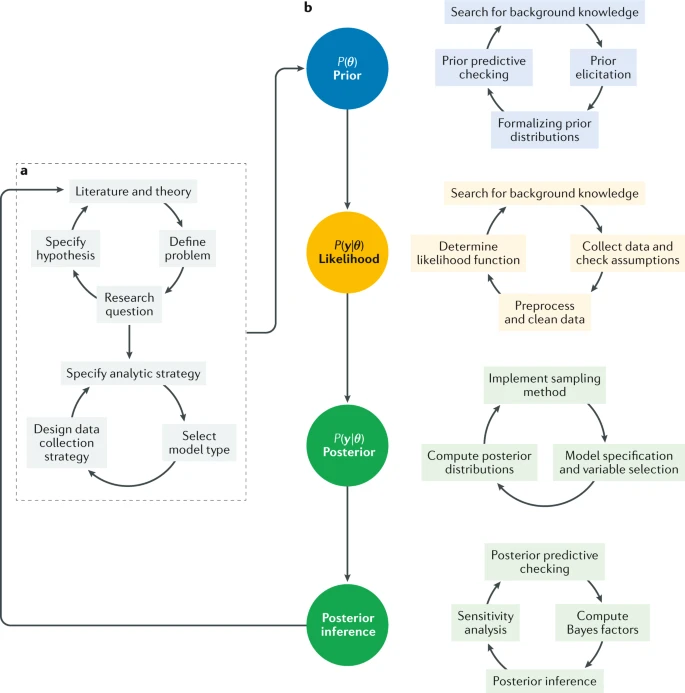

The steps needed for a research cycle using Bayesian statistics include those of a standard research cycle and a Bayesian-specific workflow. **a** | Standard research cycle involves reading literature, defining a problem and specifying the research question and hypothesis<sup>248,249</sup>. The analytic strategy can be pre-registered to enhance transparency. **b** | Bayesian-specific workflow includes formalizing prior distributions based on background knowledge and prior elicitation, determining the likelihood function by specifying a data-generating model and including observed data, and obtaining the posterior distribution as a function of both the specified prior and the likelihood function<sup>134,250</sup>. After obtaining the posterior results, inferences can be made that can then be used to start a new research cycle. *θ*, unknown parameter; *P*(.), probability distribution; *y*, data.

[Full size image](https://www.nature.com/articles/s43586-020-00001-2/figures/1)

The basis of Bayesian statistics was first described in a 1763 essay written by Reverend Thomas Bayes and published by Richard Price<sup>1</sup> on inverse probability, or how to determine the probability of a future event solely based on past events. It was not until 1825 that Pierre Simon Laplace<sup>2</sup> published the theorem we now know as Bayes’ theorem (Box [1](https://www.nature.com/articles/s43586-020-00001-2#Sec2)). Although the ideas of inverse probability and Bayes’ theorem are longstanding in mathematics, these tools became prominent in applied statistics in the past 50 years<sup>3,4,5,6,7,8,9,10</sup>. We describe many advantages and disadvantages throughout the Primer.

This Primer provides an overview of the current and future use of Bayesian statistics that is suitable for quantitative researchers working across a broad range of science-related areas that have at least some knowledge of regression modelling. We supply an overview of the literature that can be used for further study and illustrate how to implement a Bayesian model on real data. All of the data and code are available for teaching purposes. This Primer discusses the general framework of Bayesian statistics and introduces a Bayesian research cycle (Fig. 1). We first discuss formalizing of prior distributions, prior predictive checking and determining the likelihood distribution (Experimentation). We discuss relevant algorithms and model fitting, describe examples of variable selection and variational inference, and provide an example calculation with posterior predictive checking (Results). Then, we describe how Bayesian statistics are being used in different fields of science (Applications), followed by guidelines for data sharing, reproducibility and reporting standards (Reproducibility and data deposition). We conclude with a discussion on avoiding bias introduced by using incorrect models (Limitations and optimizations), and provide a look into the future with Bayesian artificial intelligence (Outlook).

### Box 1 Bayes’ theorem

Rényi’s axiom of probability<sup>253</sup> lends itself to examining conditional probabilities, where the probabilities of Event *A* and Event *B* occurring are dependent, or conditional. The basic conditional probability can be written as:

which, based on Eq. 1, can be reworked as:

which is often simplified to:

The term *p*(**θ**|*y*) represents a conditional probability, where the probability of the model parameters (*θ*) is computed conditional on the data (*y*), representing the posterior distribution. The term *p*(*y*|**θ**) represents the conditional probability of the data given the model parameters, and this term represents the likelihood function. Finally, the term *p*(**θ**) represents the probability of particular model parameter values existing in the population, also known as the prior distribution. The term *p*(**y**) is a normalizing factor and can be dropped from the equation as it does not depend on **θ**. Thus, the posterior distribution is proportional to the likelihood function multiplied by the prior distribution.

## Experimentation

This section outlines the first two steps in the Bayesian workflow described in Fig. 1. Prior distributions, shortened to priors, are first determined. The selection of priors is often viewed as one of the more important choices that a researcher makes when implementing a Bayesian model as it can have a substantial impact on the final results. The appropriateness of the priors being implemented is ascertained using the prior predictive checking process. The likelihood function, shortened to likelihood, is then determined. The likelihood is combined with the prior to form the posterior distribution, or posterior (Results). Given the important roles that the prior and the likelihood have in determining the posterior, it is imperative that these steps be conducted with care. We provide example calculations throughout to demonstrate the process.

### Formalizing prior distributions

Prior distributions play a defining role in Bayesian statistics. Priors can come in many different distributional forms, such as a normal, uniform or Poisson distribution, among others. Priors can have different levels of [informativeness](https://www.nature.com/articles/s43586-020-00001-2#Glos4); the information reflected in a prior distribution can be anywhere on a continuum from complete uncertainty to relative certainty. Although priors can fall anywhere along this continuum, there are three main classifications of priors that are used in the literature to categorize the degree of (un)certainty surrounding the population parameter value: informative, weakly informative and diffuse. These classifications can be made based on the researcher’s personal judgement. For example, a normal distribution is defined by a mean and a variance, and the variance (or width) of the distribution is linked to the level of informativeness. A variance of 1,000 may be considered diffuse in one research setting and informative in another, depending on the likelihood function as well as the scaling for the parameter.

The relationship between the likelihood, prior and posterior for different prior settings for *β*<sub>age</sub> from our example calculation predicting PhD delays is shown in Fig. 2. The first column represents the prior, which has a normal distribution for the sake of this example. The five different rows of priors represent the different prior settings based on the level of informativeness and variance from the mean. The likelihood, based on the data, is represented by a single distribution. The prior and the likelihood are combined together to create the posterior according to Bayes’ rule. The resulting posterior is dependent on the informativeness (or variance) of the prior, as well as the observed data. We demonstrate how to obtain the posterior in the Results section.

**Fig. 2: Illustration of the key components of Bayes’ theorem.**

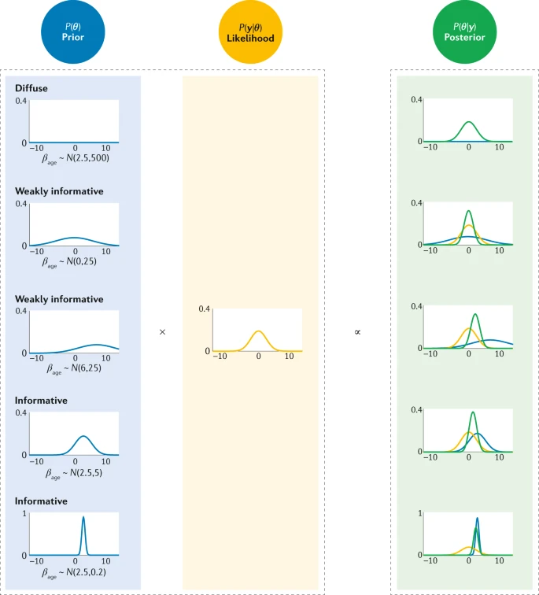

The prior distribution (blue) and the likelihood function (yellow) are combined in Bayes’ theorem to obtain the posterior distribution (green) in our calculation of PhD delays. Five example priors are provided: one diffuse, two weakly informative with different means but the same variance and two informative with the same mean but different variances. The likelihood remains constant as it is determined by the observed data. The posterior distribution is a compromise between the prior and the likelihood. In this example, the posterior distribution is most strongly affected by the type of prior: diffuse, weakly informative or informative. *β*<sub>age</sub>, linear effect of age (years); *θ*, unknown parameter; *P*(.), probability distribution; *y*, data.

[Full size image](https://www.nature.com/articles/s43586-020-00001-2/figures/2)

#### Prior elicitation

[Prior elicitation](https://www.nature.com/articles/s43586-020-00001-2#Glos6) is the process by which a suitable prior distribution is constructed. Strategies for prior elicitation include asking an expert or a panel of experts to provide values for the hyperparameters of the prior distribution<sup>14,15,16,17</sup>. MATCH<sup>18</sup> is a generic expert elicitation tool, but many methods that can be used to elicit information from experts require custom elicitation procedures and tools. For examples of elicitation procedures designed for specific models, see refs<sup>19,20,21,22,23</sup>. For an abundance of elicitation examples and methods, we refer the reader to the TU Delft expert judgement database of more than 67,000 elicited judgements<sup>24</sup> (see also<sup>14,25,26</sup>). Also, the results of a previous publication or meta-analysis can be used<sup>27,28</sup>, or any combination<sup>29</sup> or variation of such strategies.

Prior elicitation can also involve implementing databased priors. Then, the hyperparameters for the prior are derived from the sample data using methods such as maximum likelihood<sup>30,31,32,33</sup> or sample statistics<sup>34,35,36</sup>. These procedures lead to double-dipping, as the same sample data set is used to derive prior distributions and to obtain the posterior. Although databased priors are relatively common, we do not recommend the use of double-dipping procedures. Instead, a hierarchical modelling strategy can be implemented, where priors depend on hyperparameter values that are data-driven — for example, sample statistics pulled from the sample data — which avoids the direct problems linked to double-dipping. We refer the reader elsewhere<sup>34</sup> for more details on double-dipping.

#### Prior (un)certainty

An [informative prior](https://www.nature.com/articles/s43586-020-00001-2#Glos7) is one that reflects a high degree of certainty about the model parameters being estimated. For example, an informative normal prior would be expected to have a very small variance. A researcher may want to use an informative prior when existing information suggests restrictions on the possible range of a particular parameter, or a relationship between parameters, such as a positive but imperfect relationship between susceptibility to various medical conditions<sup>37,38</sup>. In some cases, an informative prior can produce a posterior that is not reflective of the population model parameter. There are circumstances when informative priors are needed, but it is also important to assess the impact these priors have on the posterior through a sensitivity analysis as discussed below. An arbitrary example of an informative prior for our empirical example is *β*<sub>age</sub> ~ *N*(2.5, 5), with a prior mean for the linear relation of age with PhD delay of 2.5 and a prior variance of 5. A ShinyApp was developed specifically for the PhD example containing a visualization of how the different priors for all parameters in the regression model interact<sup>39</sup>.

A [weakly informative prior](https://www.nature.com/articles/s43586-020-00001-2#Glos8) has a middling amount of certainty, being neither too diffuse nor too restrictive. A weakly informative normal prior would have a larger variance hyperparameter than an informative prior. Such priors will have a relatively smaller impact on the posterior compared with an informative prior, depending on the scale of the variables, and the posterior results are weighted more by the data observations as expressed in the likelihood.

Finally, a diffuse prior reflects a great deal of uncertainty about the model parameter. This prior form represents a relatively flat density and does not include specific knowledge of the parameter (Fig. 2). A researcher may want to use a diffuse prior when there is a complete lack of certainty surrounding the parameter. In this case, the data will largely determine the posterior. Sometimes, researchers will use the term non-informative prior as a synonym for diffuse<sup>42</sup>. We refrain from using this term because we argue that even a completely flat prior, such as the Jeffreys prior<sup>43</sup>, still provides information about the degree of uncertainty<sup>44</sup>. Therefore, no prior is truly non-informative.

Diffuse priors can be useful for expressing a complete lack of certainty surrounding parameters, but they can also have unintended consequences on the posterior<sup>45</sup>. For example, diffuse priors can have an adverse impact on parameter estimates via the posterior when sample sizes are small, especially in complex modelling situations involving meta-analytic models<sup>46</sup>, logistic regression models<sup>44</sup> or mixture models<sup>47</sup>. In addition, [improper priors](https://www.nature.com/articles/s43586-020-00001-2#Glos10) are sometimes used with the intention of using them as diffuse priors. Although improper priors are common and can be implemented with relative ease within various Bayesian programs, it is important to note that improper priors can lead to improper posteriors. We mention this caveat here because obtaining an improper posterior can impact the degree to which results can be substantively interpreted. Overall, we note that a diffuse prior can be used as a placeholder before analyses of the same or subsequent data are conducted with more informative priors.

#### Impact of priors

Overall, there is no right or wrong prior setting. Many times, diffuse priors can produce results that are aligned with the likelihood, whereas sometimes inaccurate or biased results can be obtained with relatively flat priors<sup>47</sup>. Likewise, an informative prior that does not overlap well with the likelihood can shift the posterior away from the likelihood, indicating that inferences will be aligned more with the prior than the likelihood. Regardless of the informativeness of the prior, it is always important to conduct a prior sensitivity analysis to fully understand the influence that the prior settings have on posterior estimates<sup>48,49</sup>. When the sample size is small, Bayesian estimation with mildly informative priors is often used<sup>9,50,51</sup>, but the prior specification might have a huge effect on the posterior results.

When priors do not conform with the likelihood, this is not necessarily evidence that the prior is not appropriate. It may be that the likelihood is at fault owing to a mis-specified model or biased data. The difference between the prior and the likelihood may also be reflective of variation that is not captured by the prior or likelihood alone. These issues can be identified through a sensitivity analysis of the likelihood, by examining different forms of the model, for example, to assess how the priors and the likelihood align.

The subjectivity of priors is highlighted by critics as a potential drawback of Bayesian methods. We argue two distinct points here. First, many elements of the estimation process are subjective, aside from prior selection, including the model itself and the error assumptions. To place the notion of subjectivity solely on the priors is a misleading distraction from the other elements in the process that are inherently subjective. Second, priors are not necessarily a point of subjectivity. They can be used as tools to allow for data-informed shrinkage, enact regularization or influence algorithms towards a likely high-density region and improve estimation efficiency. Priors are typically defined through previous beliefs, information or knowledge. Although beliefs can be characterized as subjective points of view from the researcher, information is typically quantifiable, and knowledge can be defined as objective and consensus-based. Therefore, we urge the reader to consider priors in this broader sense, and not simply as a means of incorporating subjectivity into the estimation process.

This section on informative, weakly informative and diffuse priors was written in a general sense, with these terms applicable to both univariate and multivariate priors. The majority of the discussion in this Primer pertains to univariate priors placed on individual model parameters; however, these concepts can be extended to the multivariate setting, where priors are placed on an entire covariance matrix rather than a single element from a matrix, for example. For more information on multivariate priors, see refs<sup>52,53</sup>.

### Prior predictive checking

Because inference based on a Bayesian analysis is subject to the ‘correctness’ of the prior, it is of importance to carefully check whether the specified model can be considered to be generating the actual data<sup>54,55</sup>. This is partly done by means of a process known as [prior predictive checking](https://www.nature.com/articles/s43586-020-00001-2#Glos11). Priors are based on background knowledge and cannot be inherently wrong if the prior elicitation procedure is valid, that is, if the background knowledge is correctly expressed in probability statements. However, even in the case of a valid prior elicitation procedure, it is extremely important to understand the exact probabilistic specification of the priors. This is especially true for complex models with smaller sample sizes<sup>9</sup>. Because smaller sample sizes usually convey less information, priors, in comparison, will exhibit a strong influence on the posteriors. Prior predictive checking is an exercise to improve the understanding of the implications of the specified priors on possible observations. It is not a method for changing the original prior, unless this prior explicitly generates incorrect data.

Box<sup>56</sup> suggested deriving a [prior predictive distribution](https://www.nature.com/articles/s43586-020-00001-2#Glos12) from the specified prior. The prior predictive distribution is a distribution of all possible samples that could occur if the model is true. In theory, a ‘correct’ prior provides a prior predictive distribution similar to the true data-generating distribution<sup>54</sup>. Prior predictive checking compares the observed data, or statistics of the observed data, with the prior predictive distribution, or statistics of the predictive distribution, and checks their compatibility<sup>55</sup>. For instance, values are drawn from the prior distributions. Using [kernel density estimation](https://www.nature.com/articles/s43586-020-00001-2#Glos13), a non-parametric smoothing approach used to approximate a probability density function<sup>57</sup>, the original sample and the samples from the predictive distribution can be compared<sup>58</sup>. Alternatively, the compatibility can be summarized by a [prior predictive *p*-value](https://www.nature.com/articles/s43586-020-00001-2#Glos14), describing how far the characteristics of the observed data lie in the tails of the reference prior predictive distribution<sup>59</sup>. Evans and Moshonov<sup>60,61</sup> suggested restricting Box’s approach to minimal sufficient statistics, that is, statistics that are as efficient as possible in relaying information about the value of a certain parameter from a sample<sup>62</sup>.

Young and Pettit<sup>63</sup> argued that measures based on the tail area of the prior predictive distribution, such as the approaches of Box and Evans and Moshonov, do not favour the more precise prior in cases where two priors are both specified at the correct value. Instead, they propose using a [Bayes factor](https://www.nature.com/articles/s43586-020-00001-2#Glos15)<sup>64</sup> to compare two priors (Box [2](https://www.nature.com/articles/s43586-020-00001-2#Sec10)). The Bayes factor would favour the more precise prior. These three approaches leave the determination of prior–data conflict subjective, depending on an arbitrary cut-off value. The data agreement criterion<sup>65</sup> tries to resolve the prior–data conflict determination issue by introducing a clear classification, removing the subjective element of this decision<sup>66</sup>. This is done at the expense of selecting an arbitrary divergence-based criterion. An alternative criterion has been developed<sup>67</sup> that computes whether the distance between the prior and the data is unexpected. For a comparison of both criteria, we direct the reader to Lek and van de Schoot<sup>68</sup>.

### Box 2 Bayes factors

Hypothesis testing consists of using data to evaluate the evidence for competing claims or hypotheses. In the Bayesian framework, this can be accomplished using the Bayes factor, which is the ratio of the posterior odds to the prior odds of distinct hypotheses<sup>43,64</sup>. For two hypotheses, *H*<sub>0</sub> and *H*<sub>1</sub>, and observed data *y*, the Bayes factor in favour of *H*<sub>1</sub>, denoted *BF*<sub>10</sub>, is given by:

where the prior probabilities are *p*(*H*<sub>0</sub>) and *p*(*H*<sub>1</sub>) = 1 – *p*(*H*<sub>0</sub>). A larger value of *BF*<sub>10</sub> provides stronger evidence against *H*<sub>0</sub> (ref.<sup>64</sup>). The posterior probability of hypothesis *H*<sub>*j*</sub>, *p*(*H*<sub>*j*</sub>|*y*), for *j* = 0 or 1, is obtained using Bayes theorem:

Thus, the Bayes factor can equivalently be written as the ratio of the marginal likelihoods of the observed data under the two hypotheses:

#### Empirical example 1 continued

Prior predictive checking can help prevent mistakes in the formalization of the priors. For instance, various software packages can notate the same distribution differently. The normal distribution of the prior can be specified by the hyperparameters mean and variance, mean and standard deviation or mean and precision (the inverse of the variance). To illustrate the impact of a data input error, for the informative prior with a mean of 2.5 and variance of 5 shown in Fig. 2, we also show a prior for which we have intentionally mis-specified the variance as the precision value (0.2), shown as *β*<sub>age</sub> ~ *N*(2.5, 0.2). If a user is not aware of differences between variance and precision, a prior that was intended to be weakly informative can easily turn into an informative prior distribution. Note that in this example the prior predictive distribution and the data are compared on the mean and standard deviation of the data, as these are commonly used to check prior predictive performance. The comparison statistics can, however, be chosen to reflect important characteristics of the data, such as skewness.

The prior predictive checks shown in Fig. 3 help to avoid mis-specification, for instance, when comparing the prior predictive distribution when precision is mistakenly used instead of variance (Fig. [3a](https://www.nature.com/articles/s43586-020-00001-2#Fig3)) with the distribution based on the correct hyperparameters (Fig. [3b](https://www.nature.com/articles/s43586-020-00001-2#Fig3)). We also show the kernel density estimate<sup>57</sup>, or the estimate of the probability density function, of the observed data versus simulated data (Fig. [3c](https://www.nature.com/articles/s43586-020-00001-2#Fig3)). Because of the combinations of uncertainty in the priors, the prior predictive kernel density estimates can be quite different from the observed data, and so it is also important to check that the prior predictive kernel distributions are not orders of magnitude different from the observed data.

**Fig. 3: Prior predictive checking for the PhD delay example.**

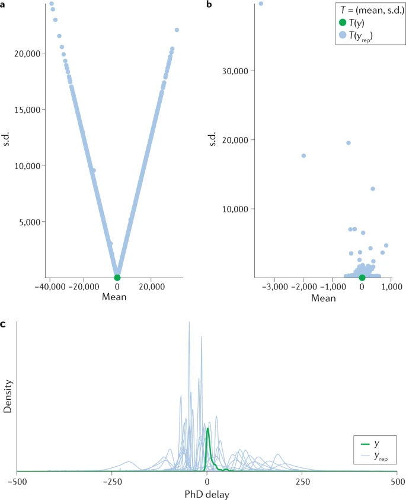

**a** | In this scenario, precision is mistakenly used instead of variance (0.2 versus 5) for the linear effect of age (years), *β*<sub>age</sub>, and the prior predictive distribution displays an unexpected pattern. The test statistic, *T*, of interest is the combination of the mean and standard deviation (s.d.): *T*(mean, s.d.). The observed combination of the mean and s.d., *T*(*y*) (green), is shown along with the same combination but now obtained from samples of the prior predictive distribution, *T*(*y*<sub>rep</sub>) (blue). **b** | In this scenario, the prior predictive distribution is shown using the correct implementation of variance. The prior predictive checks for the correct implementation of the priors seem reasonable given the data. **c** | A kernel density estimate of the observed data is displayed (*y*; green), and kernel density estimates for the samples of the prior predictive distribution (*y*<sub>rep</sub>; blue)<sup>57,58</sup>. The priors cover the entire plausible parameter space with the observed data in the centre. Computed via Stan<sup>98</sup> — the scripts are available at the Open Science Framework<sup>141</sup>.

[Full size image](https://www.nature.com/articles/s43586-020-00001-2/figures/3)

### Determining the likelihood function

The likelihood is used in both Bayesian and frequentist inference<sup>69</sup>. In both inference paradigms, its role is to quantify the strength of support the observed data lends to possible value(s) for the unknown parameter(s). The key difference between Bayesian and frequentist inference is that frequentists do not consider probability statements about the unknown parameters to be useful. Instead, the unknown parameters are considered to be fixed; the likelihood is the conditional probability distribution *p*(*y*|*θ*) of the data (*y*), given fixed parameters (*θ*). In Bayesian inference, unknown parameters are referred to as random variables in order to make probability statements about them. The (observed) data are treated as fixed, whereas the parameter values are varied; the likelihood is a function of *θ* for the fixed data *y*. Therefore, the likelihood function summarizes the following elements: a statistical model that stochastically generates all of the data, a range of possible values for *θ* and the observed data *y*.

Because the concept of likelihood is not specific to Bayesian methods, we do not provide a more elaborate introduction of the statistical concept here. Instead, we direct the interested reader to a recent tutorial<sup>70</sup> describing likelihood in common frequentist and Bayesian statistical methods. For a complete mathematical explanation on this topic, see ref.<sup>71</sup>. Much of the discussion surrounding Bayesian inference focuses on the choice of priors, and there is a vast literature on potential default priors<sup>72,73</sup>. The inclusion of available knowledge into a prior is the most noticeable difference between frequentist and Bayesian methods, and a source of controversy. The importance of the likelihood is often omitted from the discussion, even though the specified model for the data — represented by the likelihood function — is the foundation for the analysis<sup>74</sup>. The posterior distribution is the result of the prior distribution in interaction with the assumed probability model for the data in the context of the observed data<sup>72</sup>. Without the context of the likelihood in which it will be paired, the prior is often impossible to interpret.

In some cases, specifying a likelihood function can be very straightforward (Box 3). However, in practice, the underlying data-generating model is not always known. Researchers often naively choose a certain data-generating model out of habit or because they cannot easily change it in the software. Although based on background knowledge, the choice of the statistical data-generating model is subjective and should therefore be well understood, clearly documented and available to the reader. Robustness checks should be performed on the selected likelihood function to verify its influence on the posterior estimates<sup>73</sup>. Although most research on Bayesian robustness focuses on the sensitivity of the posterior results to the specification of the prior, a few contributions have focused on the sensitivity of the posterior results to the specification of the likelihood function<sup>75,76,77</sup>.

### Box 3 The likelihood function for a coin experiment

When *y* is kept fixed and *θ* is varied, *p*(*y*|θ) becomes a continuous function of *θ*, called the binomial likelihood function<sup>254</sup>.

Suppose we flipped the coin 10 times and observed 4 heads, then the likelihood function of *θ* is defined by:

## Results

After specifying the prior and the likelihood, and collecting the data, the posterior distribution can be obtained. Here, we explain how a model can be fitted to data to obtain a posterior distribution, how to select variables and why posterior predictive checking is needed. Model building is an iterative process; any Bayesian model can be viewed as a placeholder that can be improved in response to new data or lack of fit to existing data, or simply through a process of model refinement. Box<sup>56</sup>, Rubin<sup>78</sup> and Gelman et al.<sup>74</sup> discuss the fluidity of Bayesian model building, inference, diagnostics and model improvement.

### Model fitting

Once the statistical model has been defined and the associated likelihood function derived, the next step is to fit the model to the observed data to estimate the unknown parameters of the model. Although statistical models are a simplification of reality, they aim to capture the primary factors of the underlying system that we wish to improve our understanding of and which lead to the data that we observe. Models may differ substantially in their complexity, taking into account the many different possible factors or mechanisms that act on the underlying system, and sources of stochasticity and variability resulting in the given data that we observe. Fitting the models to the observed data permits the estimation of the model parameters, or functions of these, leading to an improved understanding of the system and associated underlying factors.

The frequentist framework for model fitting focuses on the expected long-term outcomes of an experiment with the intent of producing a single point estimate for model parameters such as the maximum likelihood estimate and associated confidence interval. Within the Bayesian framework for model fitting, probabilities are assigned to the model parameters, describing the associated uncertainties. In Bayesian statistics, the focus is on estimating the entire posterior distribution of the model parameters. This posterior distribution is often summarized with associated point estimates, such as the posterior mean or median, and a [credible interval](https://www.nature.com/articles/s43586-020-00001-2#Glos16). Direct inference on the posterior distribution is typically not possible, as the mathematical equation describing the posterior distribution is usually both very complicated and high-dimensional, with the number of dimensions equal to the number of parameters. The expression for the posterior distribution is typically only known up to a constant of proportionality, a constant term in the posterior distribution that is not a function of the parameters and, in general, cannot be explicitly calculated. In particular, the denominator of the expression for the posterior distribution is a function of only the data, where this function is not available in [closed form](https://www.nature.com/articles/s43586-020-00001-2#Glos17) but expressible only as an analytically intractable integral. This means that we cannot evaluate the posterior distribution exactly, and so cannot calculate, for example, associated summary statistics of interest directly. Further, the high dimensionality exacerbates these problems, so that calculating the [marginal posterior distribution](https://www.nature.com/articles/s43586-020-00001-2#Glos18) may also not be tractable, and expressible only in integral form. We note that this intractability of the posterior distribution was the primary practical reason why Bayesian statistics was discarded by many scientists in favour of frequentist statistics. The seminal article by Gelfand and Smith<sup>79</sup> described how [Markov chain Monte Carlo](https://www.nature.com/articles/s43586-020-00001-2#Glos19) (MCMC), a technique for sampling from a probability distribution, can be used to fit models to data within the Bayesian paradigm<sup>80</sup>. In particular, the MCMC algorithm only requires the probability distribution of interest to be specified up to a constant of proportionality and is scalable to high dimensions.

#### Markov chain Monte Carlo

MCMC is able to indirectly obtain inference on the posterior distribution using computer simulations<sup>80</sup>. MCMC permits a set of sampled parameter values of arbitrary size to be obtained from the posterior distribution, despite the posterior distribution being high-dimensional and only known up to a constant of proportionality. These sampled parameter values are used to obtain empirical estimates of the posterior distribution of interest. This posterior distribution, and associated summary statistics of interest, can be estimated up to the desired accuracy by increasing the number of sampled parameter values, if necessary. We note that owing to the high dimensionality of the posterior distribution, it is often useful to focus on the marginal posterior distribution of each parameter, defined by integrating out over the other parameters. Marginal distributions are useful for focusing on individual parameters but, by definition, do not provide any information on the relationship between the parameters.

[Full size table](https://www.nature.com/articles/s43586-020-00001-2/tables/1)

In general, Monte Carlo integration is a technique for estimating integrals using computer simulations of sampled values from a given distribution. Given these sampled parameter values, Monte Carlo integration permits estimation of this distribution using associated empirical estimates<sup>83</sup>. For example, for distributional summary statistics, such as the mean, variance or symmetric 95% credible interval of a parameter, we estimate these summary statistics using the corresponding sample mean, sample variance, and 2.5% and 97.5% quantile parameter values, respectively. Similarly, probability statements — such as the probability that a parameter is positive or negative, or that it lies in a range [*a*,*b*] — can be estimated as the proportion of the sampled values that satisfy the given statement. The marginal posterior distribution of any given parameter can be obtained by kernel density estimation, which uses a non-parametric approach for estimating the associated density from which sampled values have been drawn<sup>58</sup>.

It is not possible to directly and independently sample parameter values from the posterior distribution. This leads to the use of the Markov chain. The idea is to obtain a set of sampled parameter values from the posterior distribution of interest by constructing a Markov chain with a specified first-order [transition kernel](https://www.nature.com/articles/s43586-020-00001-2#Glos22), such that the resulting stationary distribution of the Markov chain is equal to this posterior distribution of interest. If the Markov chain is run sufficiently long to reach its stationary distribution, subsequent realizations of the chain can be regarded as a dependent sample from the posterior distribution, and can be used to obtain the corresponding Monte Carlo estimates (Fig. [4a](https://www.nature.com/articles/s43586-020-00001-2#Fig4)). We emphasize that the sampled parameter values obtained from the Markov chain are autocorrelated — they are dependent on their previous values in the chain — and are generated by the first-order Markov chain. The Markov chain is defined by the specification of the initial parameter values and transition kernel. The Gibbs sampler<sup>84</sup>, the Metropolis–Hastings algorithm<sup>85,86</sup> and Hamiltonian Monte Carlo<sup>87</sup> are standard approaches for defining the transition kernel so that the corresponding stationary distribution is the correct posterior distribution.

**Fig. 4: Posterior estimation using MCMC for the PhD-delays example.**

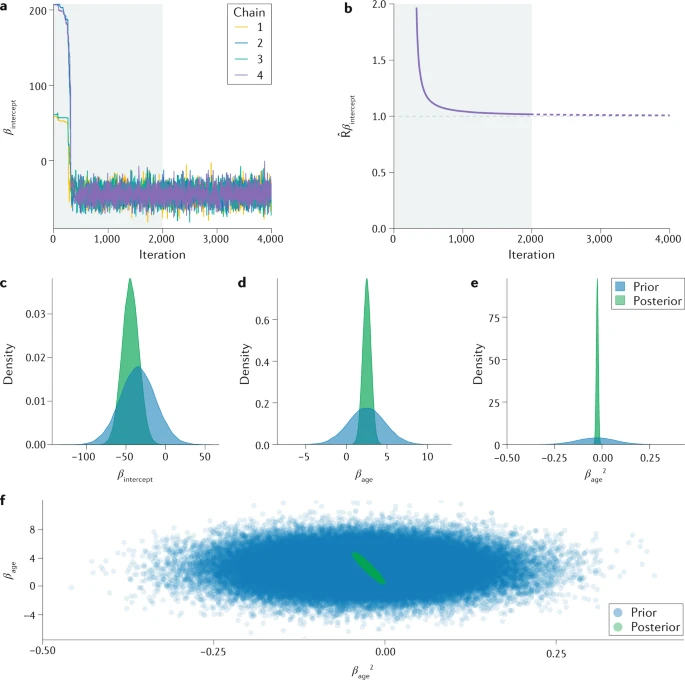

[Full size image](https://www.nature.com/articles/s43586-020-00001-2/figures/4)

#### MCMC technical aspects

Obtaining posterior inference by fitting models to observed data can be complicated owing to model complexities or data collection processes. For example, for random effect models or in the presence of latent variables, the likelihood may not be available in closed form but only expressible as an analytically intractable integral of the random effect terms or latent variables. Alternatively, the likelihood may be available in closed form, but may be multimodal — for example, for a finite mixture model or a discrete latent variable model. This, in turn, can lead to poor performance of the algorithm with one (or more) mode(s) not explored by the algorithm. In such circumstances, data augmentation is often used<sup>88</sup>, where we define additional variables, or [auxiliary variables](https://www.nature.com/articles/s43586-020-00001-2#Glos23), such that the joint distribution of the data and auxiliary variables — often referred to as the ‘complete data’ likelihood — is now available in closed form and quick to evaluate. For example, in a random effects model, auxiliary variables correspond to the individual random effect terms that would previously have been integrated out; for a finite mixture model, the auxiliary variables correspond to the mixture component to which each observation belongs. A new joint posterior distribution is then constructed over both the model parameters and the auxiliary variables; this posterior distribution is defined to be proportional to the complete data likelihood and associated prior distributions specified on the parameters. A standard MCMC algorithm can then be applied that obtains a set of sampled parameter values over both the model parameters and auxiliary variables. Discarding the auxiliary variables and considering only the values of the model parameters of interest within the Markov chain provides a sample from the original posterior distribution of the model parameters conditional on the observed data. Auxiliary variables may themselves be of interest in some cases, for example where they represent missing data values or some tangible concept such as a homogeneous subgroup (for a mixture model) or true underlying state (as for a state space model), and inference on these can be easily obtained using the sampled values.

The transition kernel determines the MCMC algorithm, describing how the parameter values and any other additional auxiliary variables are updated at each iteration of the Markov chain. In order for the stationary distribution of the Markov chain to be the posterior distribution of interest, the transition kernel is specified such that it satisfies some straightforward rules. The transition kernel is typically defined using some predefined proposal distribution: a set of new parameter values is proposed from this proposal distribution, and these values are subsequently either accepted or rejected based on a given acceptance probability, which is a function of the proposal distribution. If the proposed values are accepted, the Markov chain moves to this new state; whereas if the values are rejected, the Markov chain remains in the same state at the next iteration. We note that the transition kernel is non-unique, in that there are many possible choices for this proposal distribution that will lead to the correct stationary distribution. Common proposal distributions include: the posterior conditional distribution, leading to the Gibbs sampler where the acceptance probability in the updating step is equal to one; the Metropolis–Hastings random walk sampler, which randomly perturbs the parameter values from their current values; the slice sampler; and the No-U-Turn Sampler, among many others. We do not focus further on the internal mechanics of the MCMC algorithm here as there is a wealth of literature on this topic and, also, associated computational tools and programs for performing a Bayesian analysis using an MCMC approach. For further discussion, see, for example, refs<sup>74,89,90</sup>.

#### Assessing performance

The choice of transition kernel defines the performance of the MCMC algorithm by determining how long the Markov chain needs to be run to obtain reliable inference on the posterior distribution. [Trace plots](https://www.nature.com/articles/s43586-020-00001-2#Glos24) can display the values of the parameters over many iterations. One-dimensional trace plots are most commonly used; they describe the value of a parameter at each iteration of the Markov chain on the *y* axis against the iteration number on the *x* axis and are often a useful exploratory tool (Fig. [4a](https://www.nature.com/articles/s43586-020-00001-2#Fig4)). In particular, trace plots provide a visualization of the chain in terms of how each parameter is exploring the parameter space — referred to as mixing. If this mixing is poor, in that the chain takes a long time to explore the posterior parameter space, changes to the specified transition kernel may be required. For example, poor mixing may be due to only very small parameter value changes between successive iterations or if there is a high rejection rate of the proposed parameter values, so that the parameter values remain the same across many successive iterations of the MCMC algorithm. These plots are also informally used for identifying when the Markov chain has reached its stationary distribution. Realizations of the chain prior to convergence to its stationary distribution are discarded; this process is commonly known as burn-in, although we prefer the term warm-up and refer to this process thus in this Primer<sup>91</sup>.

The effective sample size of the sampled parameter values may be obtained to provide an indication of the efficiency of the algorithm. The effective sample size roughly expresses how many independent sampled parameter values contain the same information as the autocorrelated MCMC samples; recall that the sampled MCMC values are not independent as they are generated using a first-order Markov chain. Here, the effective sample size does not refer to the sample size of the data; rather, it is the effective length of the MCMC chain. Low sampling efficiency is related to high autocorrelation (and poor mixing) — so that the variability of the parameter values is small over successive iterations — and non-smooth histograms of posteriors. In these circumstances, longer simulations are typically required to obtain reliable estimates of the posterior distribution and sufficiently small Monte Carlo error in the estimated posterior summary statistics. The latter issue of a small effective sample size, in turn, could point towards potential problems in the model estimation or weak identifiability of the parameters<sup>21</sup>. Therefore, when problems occur in obtaining reliable Monte Carlo estimates, a good starting point is to sort all variables based on effective sample size and investigate those with the lowest effective sample size first. Effective sample size is also useful for diagnosing the sampling efficiency for a large number of variables<sup>95</sup>.

#### Computer software

[Full size table](https://www.nature.com/articles/s43586-020-00001-2/tables/2)

#### Variational inference

As we have outlined, Bayesian analysis consists of numerous stages including detailed model development, specifying the prior and data models, the derivation of exact inference approaches based on MCMC, and model checking and refinement. Each of these stages is ideally treated independently, separating model construction from its computational implementation. The focus on exact inference techniques has spurned considerable activity in developing Monte Carlo methods, which are considered the gold standard for Bayesian inference. Monte Carlo methods for Bayesian inference adopt a simulation-based strategy for approximating posterior distributions. An alternative approach is to produce functional approximations of the posterior using techniques including [variational inference](https://www.nature.com/articles/s43586-020-00001-2#Glos26)<sup>99</sup> or expectation propagation<sup>100</sup>. Here, we describe variational inference, also known as variational methods or variational Bayes, owing to its popularity and prevalence of use in machine learning.

Variational inference begins by constructing an [approximating distribution](https://www.nature.com/articles/s43586-020-00001-2#Glos27) to estimate the desired — but intractable — posterior distribution. Typically, the approximating distribution chosen is from a family of standard probability distributions, for example multivariate normal distributions, and further assumes that some of the dependencies between the variables in our model are broken to make subsequent computations tractable. In the case where the approximating distribution assumes all variables are independent, this gives us the mean-field approximation. The approximating distribution will be specified up to a set of variational parameters that we optimize to find the best posterior approximation by minimizing the Kullback–Leibler divergence from the true posterior. As a consequence, variational inference reframes Bayesian inference problems as optimization problems rather than as sampling problems, allowing them to be solved using numerical optimization. When combined with subsampling-based optimization techniques such as [stochastic gradient descent](https://www.nature.com/articles/s43586-020-00001-2#Glos28), variational inference makes approximate Bayesian inference possible for complex large-scale problems<sup>101,102,103</sup>.

### Variable selection

Variable selection is the process of identifying the subset of predictors to include in a model. It is a major component of model building along with determining the functional form of the model. Variable selection is especially important in situations where a large number of potential predictors are available. The inclusion of unnecessary variables in a model has several disadvantages, such as increasing the risk of [multicollinearity](https://www.nature.com/articles/s43586-020-00001-2#Glos29), insufficient samples to estimate all model parameters, overfitting the current data leading to poor predictive performance on new data and making model interpretation more difficult. For example, in genomic studies where high-throughput technologies are used to profile thousands of genetic markers, only a few of those markers are expected to be associated with the phenotype or outcome under investigation.

Methods for variable selection can be categorized into those based on hypothesis testing and those that perform penalized parameter estimation. In the Bayesian framework, hypothesis testing approaches use Bayes factors and posterior probabilities, whereas penalized parameter estimation approaches specify [shrinkage priors](https://www.nature.com/articles/s43586-020-00001-2#Glos30) that induce [sparsity](https://www.nature.com/articles/s43586-020-00001-2#Glos31). Bayes factors are often used when dealing with a small number of potential predictors as they involve fitting all candidate models and choosing between them. On the other hand, penalization methods fit a single model and are able to scale up to high-dimensional data.

We provide a brief review of these approaches in the context of a classical linear regression model, where the response variable from *n* independent observations, *y*, is related to *p* potential predictors defined in an *n* × *p* covariate matrix *X* via the model *y* **=** *X**β* + *ε*. The regression coefficient *β* captures the effect of the covariates on the response variable and *ε* represents the residuals assumed to follow a normal distribution with mean zero and variance *σ*<sup>2</sup>.

#### Bayes factors and posterior model probabilities

Bayes factors<sup>64</sup> (Box [2](https://www.nature.com/articles/s43586-020-00001-2#Sec10)) can be used to compare and choose between candidate models, where each candidate model corresponds to a hypothesis. Unlike frequentist hypothesis testing methods, Bayes factors do not require the models to be nested. In the context of variable selection, each candidate model corresponds to a distinct subset of the *p* potential predictors<sup>104,105</sup>. These 2<sup>*p*</sup> possible models can be indexed by a binary vector *γ* = (*γ*<sub>1</sub>, …, *γ*<sub>*p*</sub>)*'*, where *γ*<sub>*j*</sub> = 1 if covariate *X*<sub>*j*</sub> is included in the model, that is, *β*<sub>*j*</sub> ≠ 0, and *γ*<sub>*j*</sub> = 0 otherwise. Let *M*<sub>*γ*</sub> be the model that includes the *X*<sub>*j*</sub> values with *γ*<sub>*j*</sub> = 1. Prior distributions for each model, *p*(*M*<sub>*γ*</sub>), and for the parameters under each model, *p*(*β*<sub>*γ*</sub>, *σ*<sup>2</sup>|*M*<sub>*γ*</sub>), are specified, and Bayes factors *BF*<sub>*γ*b</sub> are evaluated to compare each model *M*<sub>*γ*</sub> with one of the models taken as a baseline, *M*<sub>b</sub>. The posterior probability, *p*(*M*<sub>*γ*</sub>|*y*), for each model can be expressed in terms of the Bayes factors as:

#### Shrinkage priors

**Fig. 5: Examples of shrinkage priors for Bayesian variable selection.**

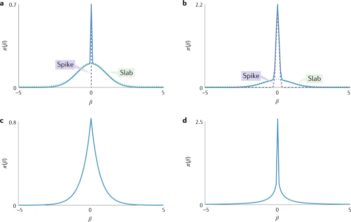

Prior density *π*(*β*) versus *β* values. **a** | The discrete spike-and-slab prior for *β* (solid line) is specified as a mixture of a point mass at zero (spike; dashed line) and a diffuse prior (slab; dotted line). **b** | The continuous spike-and-slab prior for *β* (solid line) is specified as a mixture of two normal distributions, one peaked around zero (dashed line) and the other with a large variance (dotted line). **c** | The Bayesian lasso specifies a conditional Laplace prior, which can be obtained as a scale mixture of normal distributions with an exponential mixing density. This prior does not offer enough flexibility to simultaneously allow a lot of probability mass around zero and heavy tails. **d** | The horseshoe prior falls in the class of global–local shrinkage priors, which are characterized by a high concentration around zero to shrink small coefficients and heavy tails to avoid excessive shrinkage of large coefficients.

[Full size image](https://www.nature.com/articles/s43586-020-00001-2/figures/5)

Bayesian variable selection methods have been extended to a wide variety of models. Extensions to multivariate regression models include spike-and-slab priors that select variables as relevant to either all or none of the response variables<sup>116</sup>, as well as multivariate constructions that allow each covariate to be relevant for subsets and/or individual response variables<sup>117</sup>. Other extensions include generalized linear models, random effect and time-varying coefficient models<sup>118,119</sup>, mixture models for unsupervised clustering<sup>120</sup> and estimation of single and multiple Gaussian graphical models<sup>121,122</sup>.

#### Variable selection in biomedicine

Variable selection priors for linear models have found important applications in biomedical studies. The advent of high-throughput technologies has made it possible to measure thousands of genetic markers on individual samples. Linear models are routinely used to relate large sets of biomarkers to disease-related outcomes, and variable selection methods are employed to identify significant predictors. In Bayesian approaches, additional knowledge about correlations among the variables can be easily incorporated into the analysis. For example, in models with gene expression data, spike-and-slab variable selection priors incorporating knowledge of gene-to-gene interaction networks have been employed to aid the identification of predictive genes<sup>123</sup>, as well as the identification of both relevant pathways and subsets of genes<sup>124</sup>. Bayesian variable selection priors have been successfully applied in genome-wide association studies, where hundreds of thousands of single-nucleotide polymorphisms are measured in thousands or tens of thousands of individuals, with the goal of identifying genetic variants that are associated with a single phenotype or a group of correlated traits<sup>125,126</sup>.

Air pollution is a major environmental risk factor for morbidity and mortality. Small particles produced by traffic and industrial pollution can enter the respiratory tract and have adverse health effects. Particulate matter exposure and their health effects exhibit both spatial and temporal variability, which can be factored into Bayesian models of air pollution (for a resource on Bayesian hierarchical models for spatial data we refer readers to ref.<sup>127</sup>). Spatially varying coefficient models with spike-and-slab priors inducing spatial correlation have been proposed to identify pollutants associated with adverse health outcomes, either over a whole region or within separate subregions<sup>128</sup>. Over the past couple of decades, numerous omics studies have been conducted to investigate the effects of exposure to air pollution on genomic markers and gain a better understanding of the mechanisms underlying lung injury from exposure to air pollutants. Multivariate response models with structured spike-and-slab priors that leverage the dependence between markers have been proposed to identify and estimate the effect of pollutants on DNA methylation outcomes<sup>117</sup>.

In neuroscience, neuroimaging studies often employ functional MRI, a non-invasive technique that provides an indirect measure of neuronal activity by detecting blood flow changes. These studies produce massive collections of time-series data, arising from spatially distinct locations of the brain across multiple subjects. Task-based experiments use functional MRI to scan the brain dynamically while the subject is presented to different external stimuli. The data are analysed with the goal of identifying brain regions that are activated by these stimuli. Bayesian general linear models with spatial priors, which allow flexible modelling of the correlation structure in these data, have been successfully applied<sup>129</sup>. Spike-and-slab variable selection priors that incorporate structural information on the brain have been investigated within a wide class of spatio-temporal hierarchical models for the detection of activation patterns<sup>130,131</sup>. Another application of functional MRI is in brain connectivity studies, where data are measured on subjects at rest with the aim of understanding how brain regions interact with each other. Among other approaches, multivariate vector autoregressive linear models have been investigated as a way to infer effective connectivity. Continuous shrinkage priors and structured spike-and-slab prior constructions have been employed for the selection of the active connections<sup>132,133</sup>. Bayesian variable selection methods have been successfully applied to numerous other biomedical data sets, including longitudinal data, functional data, survival outcome data and case–control studies.

### Posterior predictive checking

Once a posterior distribution for a particular model is obtained, it can be used to simulate new data conditional on this distribution that might be helpful to assess whether the model provides valid predictions so that these can be used for extrapolating to future events. Those simulations can be used for several purposes. They can be used to check whether the simulated data from the model resemble the observed data by comparing kernel density estimates of the observed data with density estimates for the simulated data<sup>57</sup>. A more formal posterior predictive checking approach can be taken to evaluate whether the model can be considered a good fit with the data-generating mechanism<sup>57,78,134,135,136</sup>. Any parameter-dependent statistic or discrepancy can be used for posterior predictive checking<sup>135</sup>. This is similar to how prior predictive checking can be used, but much more stringent in the comparison between the observed and simulated data<sup>57</sup>. The sensitivity of the posterior predictive checks is useful because if realistic models are used, the expectation is that the results are well calibrated in the long-term average<sup>78</sup>. These two uses of posterior predictive checking should be used with care; there is a risk of over-adjusting and over-refining models to the details of a specific data set. Posterior predictive distributions can further be used to extrapolate beyond the observed data and make predictions, for example extrapolating data from a time series. Based on the posterior distributions for a particular model of interest, posterior predictive distributions can be simulated for observed and future data, naturally becoming more uncertain as they predict further into the future owing to accumulated uncertainty. It is important to be aware that in temporal models there are some challenges in terms of posterior inference that are inherent to spatial and/or temporal dependencies, such as autocorrelation of parameters over time<sup>52,137,138,139</sup>.

#### Empirical example 2: Wikipedia page views

**Fig. 6: Posterior predictive checking and predicted future page views based on current observations.**

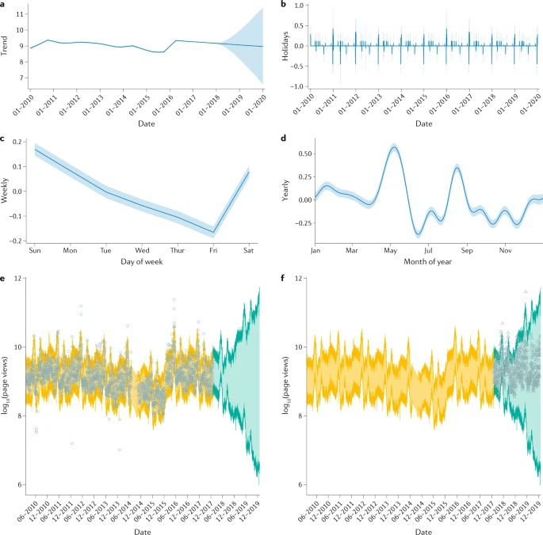

**a**–**d** | Posterior means along with 95% credible intervals (CIs) for non-periodic changes (part **a**), holiday effects (part **b**), weekly seasonality (part **c**) and yearly seasonality effects (part **d**). Displayed as how date-specific characteristics contribute to expected log<sub>10</sub>(page views). **e**,**f** | Posterior predictive distributions at each time point. Posterior predictive distributions for the time points that fall in the observed data interval on which the posterior distribution is conditioned are displayed in light yellow (50% CI) and dark yellow (95% CI), whereas posterior predictive distributions for future data are presented in light green (50% CI) and dark green (95% CI). Page view observations are marked as grey circles (part **e**). Actual page view observations for the predicted time period are marked as grey triangles, overlaid on the posterior predictive distribution (part **f**). Page views for the Wikipedia page of the English Premier League as obtained using the wikipediatrend<sup>140</sup> R package and analysed with the prophet<sup>143</sup> R package — the scripts are available at the Open Science Framework<sup>251</sup>.

[Full size image](https://www.nature.com/articles/s43586-020-00001-2/figures/6)

## Applications

Bayesian inference has been used across all fields of science. We describe a few examples here, although there are many other areas of application, such as philosophy, pharmacology, economics, physics, political science and beyond.

### Social and behavioural sciences

A recent systematic review examining the use of Bayesian statistics reported that the social and behavioural sciences — psychology, sociology and political sciences — have experienced an increase in empirical Bayesian work<sup>4</sup>. Specifically, there have been two parallel uses of Bayesian methods that have been increasing in popularity within the social and behavioural sciences: theory development and as a tool for model estimation.

Bayes’ rule has been used as an underlying theory for understanding reasoning, decision-making, cognition and theories of mind, and has been particularly prevalent in developmental psychology and related fields. Bayes’ rule was used as a conceptual framework for cognitive development in young children, capturing how children develop an understanding of the world around them<sup>144</sup>. Bayesian methodology has also been discussed in terms of enhancing cognitive algorithms used for learning. Gigerenzer and Hoffrage<sup>145</sup> discuss the use of frequencies, rather than probabilities, as a method to improve on Bayesian reasoning. In another seminal article, Slovic and Lichtenstein<sup>146</sup> discuss how Bayesian methods can be used for judgement and decision-making processes. Within this area of the social and behavioural sciences, Bayes’ rule has been used as an important conceptual tool for developing theories and understanding developmental processes.

The social and behavioural sciences are a terrific setting for implementing Bayesian inference. The literature is rich with information that can be used to derive prior distributions. Informative priors are useful in complex modelling situations, which are common in the social sciences, as well as in cases of small sample sizes. Certain models that are used to explore education outcomes and standardized tests, such as some multidimensional item response theory models, are intractable using frequentist statistics and require the use of Bayesian methods.

The number of publications concerning Bayesian statistics has been steadily rising since 2004, with a more notable increase in the last decade. In part, this focus on Bayesian methods is owing to the development of more accessible software, as well as a focus on publishing tutorials targeting applied social and behavioural scientists. A systematic review of Bayesian methods in the field of psychology uncovered 740 eligible regression-based articles using Bayesian methods. Of these, 100 articles (13.5%) were tutorials for implementing Bayesian methods, and an additional 225 articles (30.4%) were either technical papers or commentaries on Bayesian statistics (Box [4](https://www.nature.com/articles/s43586-020-00001-2#Sec30)). Methodologists have been attempting to guide applied researchers towards using Bayesian methods within the social and behavioural sciences, although the implementation has been relatively slow to catch on. For example, the systematic review found that only 167 regression-based Bayesian articles (22.6%) were applications using human samples. Nevertheless, some subfields are regularly publishing work implementing Bayesian methods.

The field has gained many interesting insights into psychological and social behaviour through Bayesian methods, and the substantive areas in which this work has been conducted are quite diverse. For example, Bayesian statistics has helped to uncover the role that craving suppression has in smoking cessation<sup>147</sup>, to make population forecasts based on expert opinions<sup>148</sup>, to examine the role that stress related to infant care has in divorce<sup>149</sup>, to examine the impact of the President of the USA’s ideology on US Supreme Court rulings<sup>150</sup> and to predict behaviours that limit the intake of free sugars in one’s diet<sup>151</sup>. These examples all represent different ways in which Bayesian methodology is captured in the literature. It is common to find papers that highlight Bayes’ rule as a mechanism to explain theories of development and critical thinking<sup>144</sup>, that are expository<sup>152,153</sup>, that focus on how Bayesian reasoning can inform theory through use of Bayesian inference<sup>154</sup> and that use Bayesian modelling to extract findings that would have been difficult to derive using frequentist methods<sup>147</sup>. Overall, there is broad use of Bayes’ rule within the social and behavioural sciences.

We argue that the increased use of Bayesian methods in the social and behavioural sciences is a great benefit to improving substantive knowledge. However, we also feel that the field needs to continue to develop strict implementation and reporting standards so that results are replicable and transparent. We believe that there are important benefits to implementing Bayesian methods within the social sciences, and we are optimistic that a strong focus on reporting standards can make the methods optimally useful for gaining substantive knowledge.

### Box 4 Bayesian methods in the social and behavioural sciences

Hoijtink et al.<sup>255</sup> discuss the use of Bayes factors for informative hypotheses within cognitive diagnostic assessment, illustrating how Bayesian evaluation of informative diagnostics hypotheses can be used as an alternative approach to traditional diagnostic methods. There is added flexibility with the Bayesian approach as informative diagnostic hypotheses can be evaluated using the Bayes factor utilizing only data from the individual being diagnosed. Lee<sup>154</sup> present an overview of the application of Bayes’ theorem in the field of cognitive psychology, discussing how Bayesian methods can be used to develop more complete theories of cognitive psychology. Bayesian methods can also account for observed behaviour in terms of different cognitive processes, explain behaviour on a wide range of cognitive tasks and provide a conceptual unification of different cognitive models. Depaoli et al.<sup>152</sup> show how Bayesian methods can benefit health-based research being conducted in psychology by highlighting how informative priors elicited with expert knowledge and previous research can be used to better understand the physiological impact of a health-based stressor. In this research scenario, frequentist methods would not have produced viable results because the sample size was relatively small for the model being estimated owing to the cost of data collection and the population being difficult to access for sampling. Finally, Kruschke<sup>153</sup> present the simplest example using a *t-*test geared towards experimental psychologists, showing how Bayesian methods can benefit the interpretation of any model parameter. This paper highlights the Bayesian way of interpreting results, focusing on the interpretation of the entire posterior rather than a point estimate.

### Ecology

The application of Bayesian analyses to answer ecological questions has become increasingly widespread owing to both philosophical arguments, particularly in terms of subjective versus objective reasoning, and practical model-fitting advantages. This is combined with readily available software (Table 2) and numerous publications describing Bayesian ecological applications using these software packages (see refs<sup>155,156,157,158,159,160,161</sup> for examples). The underlying Bayesian philosophy is attractive in many ways within ecology<sup>162</sup> as it permits the incorporation of external, independent prior information either from previous studies on the same/similar species or inherent knowledge of the biological processes within a rigorous framework<sup>163,164</sup>. Further, the Bayesian approach also permits both direct probabilistic statements to be made on parameters of interest, such as survival probabilities, reproductive rates, population sizes and future predictions<sup>157</sup>, and the calculation of relative probabilities of competing models — such as the presence or absence of density dependence or environmental factors in driving the dynamics of the ecosystem — that in turn permits model-averaged estimates incorporating both parameter and model uncertainty. The ability to provide probabilistic statements is particularly useful in relation to wildlife management and conservation. For example, King et al.<sup>165</sup> provide probability statements in relation to the level of population decline over a given time period, which in turn provides probabilities associated with species’ conservation status.

A Bayesian approach is also often applied in ecological research for pragmatic reasons. Many ecological models are complex — for example, they may be spatio-temporal in nature, high-dimensional and/or involving multiple interacting biological processes — leading to computationally expensive likelihoods that are slow to evaluate. Imperfect or limited data collection processes often lead to missing data and associated intractable likelihoods. In such circumstances, standard Bayesian model-fitting tools such as data augmentation may permit the models to be fitted, whereas in the alternative frequentist framework additional model simplifications or approximations may be required. The application of Bayesian statistics in ecology is vast and encompasses a range of spatio-temporal scales from an individual organism level to an ecosystem level that includes understanding the population dynamics of the given system<sup>166</sup>, modelling spatial point pattern data<sup>167</sup>, investigating population genetics, estimating abundance<sup>168</sup> and assessing conservation management<sup>169</sup>.

Ecological data collection processes generally come from observational studies, where a sample is observed from the population of interest using some data survey protocol. The survey should be carefully designed, taking into account the ecological question(s) of interest and minimizing the complexity of the model required to fit the data to provide reliable inference. Nevertheless, associated model-fitting challenges may still arise owing to data collection problems, such as those resulting from equipment failure or poor weather conditions. There may also be inherent data collection problems in some data surveys, such as the inability to record individual-level information. Such model-fitting challenges may include — but are far from limited to — irregularly spaced observations in time owing to equipment failure or experimental design, measurement error due to imperfect data observations, missing information at a range of different levels, from the individual level to the global environmental level, and challenges associated with multiscaled studies where different aspects of data are recorded at different temporal scales — for example, from hourly location data of individuals to daily and monthly collections of environmental data. The data complexities that arise, combined with the associated modelling choices, may lead to a range of model-fitting challenges that can often be addressed using standard techniques within the Bayesian paradigm.

For a given ecological study, separating out the individual processes acting on the ecosystem is an attractive mechanism for simplifying model specification<sup>166</sup>. For example, state space models provide a general and flexible modelling framework that describes two distinct types of process: the system process and the observation process. The system process describes the true underlying state of the system and how this changes over time. This state may be univariate or multivariate, such as population size or location data, respectively. The system process may also describe multiple processes acting on the system, such as birth, reproduction, dispersal and death. We are typically not able to observe these true underlying system states without some associated error and the observation process describes how the observed data relate to the true unknown states. These general state space models span many applications, including animal movement<sup>170</sup>, population count data<sup>171</sup>, capture–recapture-type data<sup>165</sup>, fisheries stock assessment<sup>172</sup> and biodiversity<sup>173</sup>. For a review of these topics and further applications, we direct the reader elsewhere<sup>166,174,175</sup>. Bayesian model-fitting tools, such as MCMC with data augmentation<sup>176</sup>, sequential Monte Carlo or particle MCMC<sup>177,178,179</sup>, permit general state space models to be fitted to the observed data without the need to specify further restrictions — such as distributional assumptions — on the model specification, or to make additional likelihood approximations.

The process of collecting data continues to evolve with advances in technology. For example, the use of GPS geolocation tags and associated additional accelerometers, remote sensing, the use of drones for localized aerial photographs, unmanned underwater vehicles and motion-sensor camera traps are increasingly used within ecological research. The use of these technological devices and the growth of crowdsourced science have led to new forms of data collected in great quantities and associated model-fitting challenges, providing a fertile ground for Bayesian analyses.

### Genetics

Genetics and genomics studies have made extensive use of Bayesian methods. In genome-wide association studies, Bayesian approaches have provided a powerful alternative to frequentist approaches for assessing associations between genetic variants and a phenotype of interest in a population<sup>180</sup>. These include statistical models for incorporating genetic admixture<sup>181</sup>, fine-mapping to identify causal genetic variants<sup>182</sup>, imputation of genetic markers not directly measured using reference populations<sup>183</sup> and meta-analysis for combining information across studies. These applications further benefit from the use of marginalization to account for modelling uncertainties when drawing inferences. More recently, large cohort studies such as the UK Biobank<sup>184</sup> have expanded the methodological requirements for identifying genetic associations with complex (sub)phenotypes by collating genetic information alongside heterogeneous data sets including imaging, lifestyle and routinely collected health data. A Bayesian analysis framework known as TreeWAS<sup>185</sup> has extended genetic association methods to allow for the incorporation of tree-structured disease diagnosis classifications by modelling the correlation structure of genetic effects across observed clinical phenotypes. This approach incorporates prior knowledge of phenotype relationships that can be derived from a diagnosis classification tree, such as information from the latest version of the International Classification of Diseases (ICD-10).

The availability of multiple molecular data types in multi-omics data sets has also attracted Bayesian solutions to the problem of multimodal data integration. Bayesian latent variable models can be used as an unsupervised learning approach to identify latent structures that correspond to known or previously uncharacterized biological processes across different molecular scales. Multi‐omics factor analysis<sup>186</sup> uses a Bayesian linear factor model to disentangle sources of heterogeneity that are common across multiple data modalities from those patterns that are specific to only a single data modality.

In recent years, high-throughput molecular profiling technologies have advanced to allow the routine multi-omics analysis of individual cells<sup>187</sup>. This has led to the development of many novel approaches for modelling single-cell measurement noise, cell-to-cell heterogeneity, high dimensionality, large sample sizes and interventional effects from, for example, genome editing<sup>188</sup>. Cellular heterogeneity lends itself naturally to Bayesian hierarchical modelling and formal uncertainty propagation and quantification owing to the layers of variability induced by tissue-specific activity, heterogeneous cellular phenotypes within a given tissue and stochastic molecular expression at the level of the single cell. In the integrated Bayesian hierarchical model BASiCS<sup>189</sup>, this approach is used to account for cell-specific normalization constants and technical variability to decompose total gene expression variability into technical and biological components.

Deep neural networks (DNNs) have also been utilized to specify flexible, non-linear conditional dependencies within hierarchical models for single-cell omics. SAVER-X<sup>190</sup> couples a Bayesian hierarchical model with a pretrainable deep [autoencoder](https://www.nature.com/articles/s43586-020-00001-2#Glos36) to extract transferable gene–gene relationships across data sets from different laboratories, variable experimental conditions and divergent species to de-noise novel target data sets. In scVI<sup>191</sup>, hierarchical modelling is used to pool information across similar cells and genes to learn models of the distribution of observed expression values. Both SAVER-X and scVI perform approximate Bayesian inference using mini-batch stochastic gradient descent, the latter within a variational setting — a standard technique in DNNs — that allow these models to be fitted to hundreds of thousands or even millions of cells.

Bayesian approaches have also been popular in large-scale cancer genomic data sets<sup>192</sup> and have enabled a data-driven approach to identifying novel molecular changes that drive cancer initiation and progression. Bayesian network models<sup>193</sup> have been developed to identify the interactions between mutated genes and capture mutational signatures that highlight key genetic interactions with the potential to allow for genomic-based patient stratification in both clinical trials and the personalized use of therapeutics. Bayesian methods have also been important in answering questions about evolutionary processes in cancer. Several Bayesian approaches for phylogenetic analysis of heterogeneous cancers enable the identification of the distinct subpopulations that can exist with tumours and their ancestral relationships through the analysis of single-cell and bulk tissue-sequencing data<sup>194</sup>. These models therefore consider the joint problem of learning a mixture model and graph inference through considering the number and identity of the subpopulations and deriving the phylogenetic tree.

## Reproducibility and data deposition

Proper reporting on statistics, including sharing of data and scripts, is a crucial element in the verification and reproducibility of research<sup>195</sup>. A workflow incorporating good research practices that encourage reproducibility in the Bayesian research cycle is displayed in Fig. 7. We demonstrate where the Bayesian research cycle (Fig. 1) and the WAMBS (when to Worry and how to Avoid the Misuse of Bayesian Statistics) checklist<sup>48,81</sup> fit in the wider context of transparency in research, and we offer an updated version of the WAMBS checklist (Box [5](https://www.nature.com/articles/s43586-020-00001-2#Sec34)). In this section, we highlight some important aspects of reproducibility and the deposition of data and scripts.

**Fig. 7: Elements of reproducibility in the research workflow.**

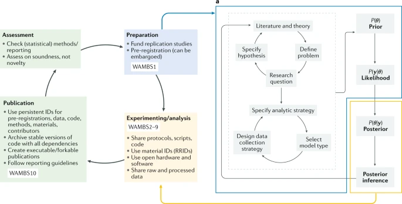

Good research practices across the research workflow that can contribute to reproducibility, demonstrating where the Bayesian research cycle (part **a**) and the WAMBS (when to Worry and how to Avoid the Misuse of Bayesian Statistics) checklist fit in the wider context of transparency in research<sup>252</sup>. Not all elements are applicable to all types of research — for example, pre-registration is typically used for hypothesis-driven research — but the specification of the prior and the likelihood may be pre-registered. There may be legitimate reasons why data cannot be shared openly, but all scripts for running the Bayesian models could be shared on a data repository. *θ*, unknown parameter; RRID, Research Resource Identifier; *P*(.), probability distribution; *y*, data.

[Full size image](https://www.nature.com/articles/s43586-020-00001-2/figures/7)

Allowing others to assess the statistical methods and underlying data used in a study (by transparent reporting and making code and data available) can help with interpreting the study results, the assessment of the suitability of the parameters used and the detection and fixing of errors. Reporting practices are not yet consistent across fields or even journals in individual fields. A systematic review on Bayesian statistics in psychology<sup>4</sup> found huge discrepancies in reporting practices and standards across the social sciences; for example, of the 167 regression-based Bayesian articles using human samples in psychology, 31% did not mention the priors that were implemented, 43.1% did not report on chain convergence and only 40% of those implementing informative priors conducted a sensitivity analysis. We view this as a major impediment to the implementation of Bayesian statistics within the social and behavioural sciences, as well as other fields of research.

Not reporting any information on the priors is problematic for any Bayesian paper. There are many dangers in naively using priors and, we argue, one might want to pre-register the specification of the priors and the likelihood when possible. Moreover, the impact of priors on final model estimates can be easily overlooked — a researcher may estimate a model with certain priors and be unaware that using different priors with the same model and data can result in substantively different results. In both cases, the results could look completely viable, with Markov chains that appear to be converged and posteriors that appear appropriate and informative. Without examining the impact of priors through a sensitivity analysis and prior predictive checking, the researcher would not be aware of how sensitive results are to changes in the priors. Consider the prior variance in the PhD delay example for *β*<sub>age</sub> that was mis-specified, using precision instead of variance (Fig. 3).

To enable reproducibility and allow others to run Bayesian statistics on the same data with different parameters, priors, models or likelihood functions for sensitivity analyses<sup>49</sup>, it is important that the underlying data and code used are properly documented and shared following the FAIR principles<sup>196,197</sup>: findability, accessibility, interoperability and reusability. Preferably, data and code should be shared in a trusted repository ([Registry of Research Data Repositories](https://www.re3data.org/)) with their own persistent identifier (such as a DOI), and tagged with metadata describing the data set or codebase. This also allows the data set and the code to be recognized as separate research outputs and allows others to cite them accordingly<sup>198</sup>. Repositories can be general, such as Zenodo; language-specific, such as CRAN for R packages and PyPI for Python code; or domain-specific<sup>198</sup>. As data and code require different licence options and metadata, data are generally best stored in dedicated data repositories, which can be general or discipline-specific<sup>199</sup>. Some journals, such as *Scientific Data*, have their own list of recommended data repositories. To make depositing data and code easier for researchers, two repositories ([Zenodo](https://zenodo.org/) and [Dryad](https://datadryad.org/)) are exploring collaboration to allow the deposition of code and data through one interface, with data stored in Dryad and code stored in Zenodo<sup>200</sup>. Many scientific journals adhere to transparency and openness promotion guidelines<sup>201</sup>, which specify requirements for code and data sharing.

Verification and reproducibility require access to both the data and the code used in Bayesian modelling, ideally replicating the original environment in which the code was run, with all dependencies documented either in a dependency file accompanying the code or by creating a static container image that provides a virtual environment in which to run the code<sup>199</sup>. Open-source software should be used as much as possible, as open sources reduce the monetary and accessibility threshold to replicating scientific results. Moreover, it can be argued that closed-source software keeps part of the academic process hidden, including from the researchers who use the software themselves. However, open-source software is only truly accessible with proper documentation, which includes listing dependencies and configuration instructions in Readme files, commenting on code to explain functionality and including a comprehensive reference manual when releasing packages.

WAMBS-v2, an updated version of the WAMBS (when to Worry and how to Avoid the Misuse of Bayesian Statistics) checklist.

## Limitations and optimizations

The optimization of Bayesian inference is conditional on the assumed model. Bayesian posterior probabilities are calibrated as long-term averages if parameters are drawn from the prior distribution and data are drawn from the model of the data given these parameters. Events with a stated probability occur at that frequency in the long term, when averaging over the generative model. In practice, our models are never correct. There are two ways we would like to overcome this limitation: by identifying and fixing problems with the model; and by demonstrating that certain inferences are robust to reasonable departures from the model.

Even the simplest and most accepted Bayesian inferences can have serious limitations. For example, suppose an experiment is conducted yielding an unbiased estimate *z* of a parameter *θ* that represents the effect of some treatment. If this estimate *z* is normally distributed with standard error *s*, we can write *z* ~ *N*(*θ*, *s*<sup>2</sup>), a normal distribution parameterized by its location and scale parameter. Suppose that *θ* has a flat uniform prior distribution, then the posterior distribution is *θ* ~ *N*(*z*, *s*<sup>2</sup>). Now suppose we observe *z* = *s*; that is, the estimate of *θ* is one standard error from zero. This would be considered statistically indistinguishable from noise, in the sense that such an estimate could occur by chance, even if the true parameter value was zero. But the Bayesian calculation gives a posterior probability Pr(*θ* > 0|*z*) = 0.84. This makes the calibration of the probability questionable (calibrated inferences or predictions are correct on average, conditional on the prediction).

so Pr(*θ* > 0|*z*) = 0.76, compared with 0.84 from our previous example. Ultimately, only a strong prior will make a big difference. Bayesian probabilities are only calibrated when averaging over the true prior or population distribution of the parameters. The important thing about this example is not the specific numbers, which will depend on the context, but the idea that any statistical method should be evaluated over the range of problems to which it will be applied.

More generally, Bayesian models can be checked by comparing posterior predictive simulations with data<sup>135</sup> and by estimating the out-of-sample predictive error<sup>202</sup>. There is a benefit to strong prior distributions that constrain parameters to reasonable values to allow the inclusion of more data while avoiding overfitting. More data can come from various sources, including additional data points, additional measurements on existing data and prior information summarizing other data or theories. All methods, Bayesian and otherwise, require subjective interpretation to tell a plausible story, and all models come from researcher decisions. Any choice of model has implications; the flat prior is weak, providing no shrinkage of the estimate, but can lead to a strong, possibly inappropriate, level of certainty about *θ*.

## Outlook

The widespread adoption of Bayesian statistics across disciplines is a testament to the power of the Bayesian paradigm for the construction of powerful and flexible statistical models within a rigorous and coherent probability framework. Modern Bayesian practitioners have access to a wealth of knowledge and techniques that allow the creation of bespoke models and computational approaches for particular problems. Probabilistic programming languages, such as Stan, can take away much of the implementation details for many applications, allowing the focus to remain on the fundamentals of modelling and design.

An ongoing challenge for Bayesian statistics is the ever-growing demands posed by increasingly complex real-world applications, which are often associated with issues such as large data sets and uncertainties regarding model specification. All of this occurs within the context of rapid advances in computing hardware, the emergence of novel software development approaches and the growth of data sciences, which has attracted a larger and more heterogeneous scientific audience than ever before. In recent years, the revision and popularization of the term artificial intelligence to encompass a broad range of ideas including statistics and computation has blurred the traditional boundaries between these disciplines. This has been hugely successful in popularizing probabilistic modelling and Bayesian concepts outside their traditional roots in statistics, but has also seen transformations in the way Bayesian inference is being carried out and new questions about how Bayesian approaches can continue to be at the innovative forefront of research in artificial intelligence.

Driven by the need to support large-scale applications involving data sets of increasing dimensionality and sample numbers, Bayesian concepts have exploited the growth of new technologies centred on deep learning. This includes deep learning programming frameworks (TensorFlow<sup>203</sup>, PyTorch<sup>204</sup>), which simplify the use of DNNs, permitting the construction of more expressive, data-driven models that are immediately amenable to inference techniques using off-the-shelf optimization algorithms and state-of-the-art hardware. In addition to providing a powerful tool to specify flexible and modular generative models, DNNs have been employed to develop new approaches for approximate inference and stimulated a new paradigm for Bayesian practice that sees the integration of statistical modelling and computation at its core.

An archetypal example is the variational autoencoder<sup>205</sup>, which has been successfully used in various applications, including single-cell genomics<sup>190,191</sup>, providing a general modelling framework that has led to numerous extensions including latent factor disentanglement<sup>206,207,208</sup>. The underlying statistical model is a simple Bayesian hierarchical latent variable model, which maps high-dimensional observations to low-dimensional latent variables assumed to be normally distributed through functions defined by DNNs. Variational inference is used to approximate the posterior distribution over the latent variables. However, in standard variational inference we would introduce a local variational parameter for each latent variable, in which case the computational requirements would scale linearly with the number of data samples. Variational autoencoders use a further approximation process known as [amortization](https://www.nature.com/articles/s43586-020-00001-2#Glos38) to replace inference over the many individual variational parameters with a single global set of parameters — known as a recognition network — that are used to parameterize a DNN that outputs the local variational parameters for each data point.

Remarkably, when the model and inference are combined and interpreted together, the variational autoencoder has an elegant interpretation as an encoding-decoding algorithm: it consists of a probabilistic encoder — a DNN that maps every observation to a distribution in the latent space — and a probabilistic decoder — a complementary DNN that maps each point in the latent space to a distribution in the observation space. Thus, model specification and inference have become entangled within the variational autoencoder, demonstrating the increasingly blurry boundary between principled Bayesian modelling and algorithmic deep learning techniques. Other recent examples include the use of DNNs to construct probabilistic models that define distributions over possible functions<sup>209,210,211</sup>, build complex probability distributions by applying a sequence of invertible transformations<sup>212,213</sup> and define models for exchangeable sequence data<sup>214</sup>.

The expressive power of DNNs and their utility within model construction and inference algorithms come with compromises that will require Bayesian research. The trend towards entangling models and inference has popularized these techniques for large-scale data problems; however, fundamental Bayesian concepts remain to be fully incorporated within this paradigm. Integrating-out, model-averaging decision theoretic approaches rely on accurate posterior characterization, which remains elusive owing to the challenge posed by high-dimensional neural network parameter spaces<sup>215</sup>. Although Bayesian approaches to neural network learning have been around for decades<sup>216,217,218,219</sup>, further investigation into prior specifications for modern Bayesian deep learning models that involve complex network structures is required to understand how priors translate to specific functional properties<sup>220</sup>.

Recent debates within the field of artificial intelligence have questioned the requirement for Bayesian approaches and highlighted potential alternatives. For instance, deep ensembles<sup>221</sup> have been shown to be alternatives to Bayesian methods for dealing with model uncertainty. However, more recent work has shown that deep ensembles can actually be reinterpreted as approximate Bayesian model averaging<sup>222</sup>. Similarly, dropout is a regularization approach popularized for use in the training of DNNs to improve robustness by randomly dropping out nodes during the training of the network<sup>223</sup>. Dropout has been empirically shown to improve generalizability and reduce overfitting. Bayesian interpretations of dropout have emerged, linking it to forms of Bayesian approximation of probabilistic deep Gaussian processes<sup>224</sup>. Although the full extent of Bayesian principles has not yet been generalized to all recent developments in artificial intelligence, it is nonetheless a success that Bayesian thinking is deeply embedded and crucial to numerous innovations that have arisen. The next decade is sure to bring a new wave of exciting innovative developments for Bayesian intelligence.

## References

1. 1.

   Bayes, M. & Price, M. LII. An essay towards solving a problem in the doctrine of chances. By the late Rev. Mr. Bayes, F. R. S. communicated by Mr. Price, in a letter to John Canton, A. M. F. R. S. *Philos. Trans. R Soc. Lond. B Biol. Sci.* **53**, 370–418 (1997).

   [ADS](http://adsabs.harvard.edu/cgi-bin/nph-data_query?link_type=ABSTRACT&bibcode=1763RSPT...53..370B) [MATH](http://www.emis.de/MATH-item?1250.60007) Google Scholar
2. 2.

   Laplace, P. S. *Essai Philosophique sur les Probabilities* (Courcier, 1814).
3. 3.

   König, C. & van de Schoot, R. Bayesian statistics in educational research: a look at the current state of affairs. *Educ. Rev.* https://doi.org/10.1080/00131911.2017.1350636 (2017).

   [Article](https://doi.org/10.1080%2F00131911.2017.1350636) Google Scholar
4. 4.

   van de Schoot, R., Winter, S., Zondervan-Zwijnenburg, M., Ryan, O. & Depaoli, S. A systematic review of Bayesian applications in psychology: the last 25 years. *Psychol. Methods* **22**, 217–239 (2017).

   Google Scholar
5. 5.

   Ashby, D. Bayesian statistics in medicine: a 25 year review. *Stat. Med.* **25**, 3589–3631 (2006).

   [MathSciNet](http://www.ams.org/mathscinet-getitem?mr=2252415) [Google Scholar](http://scholar.google.com/scholar_lookup?&title=Bayesian%20statistics%20in%20medicine%3A%20a%2025%20year%20review&journal=Stat.%20Med.&volume=25&pages=3589-3631&publication_year=2006&author=Ashby%2CD)
6. 6.

   Rietbergen, C., Debray, T. P. A., Klugkist, I., Janssen, K. J. M. & Moons, K. G. M. Reporting of Bayesian analysis in epidemiologic research should become more transparent. *J. Clin. Epidemiol.* https://doi.org/10.1016/j.jclinepi.2017.04.008 (2017).

   [Article](https://doi.org/10.1016%2Fj.jclinepi.2017.04.008) Google Scholar
7. 7.

   Spiegelhalter, D. J., Myles, J. P., Jones, D. R. & Abrams, K. R. Bayesian methods in health technology assessment: a review. *Health Technol. Assess.* https://doi.org/10.3310/hta4380 (2000).

   [Article](https://doi.org/10.3310%2Fhta4380) Google Scholar
8. 8.

   Kruschke, J. K., Aguinis, H. & Joo, H. The time has come: Bayesian methods for data analysis in the organizational sciences. *Organ. Res. Methods* **15**, 722–752 (2012).

   Google Scholar
9. 9.

   Smid, S. C., McNeish, D., Miočević, M. & van de Schoot, R. Bayesian versus frequentist estimation for structural equation models in small sample contexts: a systematic review. *Struct. Equ. Modeling* **27**, 131–161 (2019).

   [MathSciNet](http://www.ams.org/mathscinet-getitem?mr=4054423) Google Scholar
10. 10.

    Rupp, A. A., Dey, D. K. & Zumbo, B. D. To Bayes or not to Bayes, from whether to when: applications of Bayesian methodology to modeling. *Struct. Equ. Modeling* **11**, 424–451 (2004).

    [MathSciNet](http://www.ams.org/mathscinet-getitem?mr=2061898) Google Scholar
11. 11.

    van de Schoot, R., Yerkes, M. A., Mouw, J. M. & Sonneveld, H. What took them so long? Explaining PhD delays among doctoral candidates. *PloS ONE* **8**, e68839 (2013).

    [ADS](http://adsabs.harvard.edu/cgi-bin/nph-data_query?link_type=ABSTRACT&bibcode=2013PLoSO...868839V) Google Scholar
12. 12.

    van de Schoot, R. Online stats training. *Zenodo* https://zenodo.org/communities/stats_training (2020).
13. 13.

    Heo, I. & van de Schoot, R. Tutorial: advanced Bayesian regression in JASP. *Zenodo* https://doi.org/10.5281/zenodo.3991325 (2020).

    [Article](https://doi.org/10.5281%2Fzenodo.3991325) [Google Scholar](http://scholar.google.com/scholar_lookup?&title=Tutorial%3A%20advanced%20Bayesian%20regression%20in%20JASP&journal=Zenodo&doi=10.5281%2Fzenodo.3991325&publication_year=2020&author=Heo%2CI&author=Schoot%2CR)
14. 14.

    O’Hagan, A. et al. *Uncertain Judgements: Eliciting Experts’ Probabilities* (Wiley, 2006). **This book presents a great collection of information with respect to prior elicitation, and includes elicitation techniques, summarizes potential pitfalls and describes examples across a wide variety of disciplines**.
15. 15.

    Howard, G. S., Maxwell, S. E. & Fleming, K. J. The proof of the pudding: an illustration of the relative strengths of null hypothesis, meta-analysis, and Bayesian analysis. *Psychol. Methods* **5**, 315–332 (2000).

    Google Scholar
16. 16.

    Veen, D., Stoel, D., Zondervan-Zwijnenburg, M. & van de Schoot, R. Proposal for a five-step method to elicit expert judgement. *Front. Psychol.* **8**, 2110 (2017).

    Google Scholar
17. 17.

    Johnson, S. R., Tomlinson, G. A., Hawker, G. A., Granton, J. T. & Feldman, B. M. Methods to elicit beliefs for Bayesian priors: a systematic review. *J. Clin. Epidemiol.* **63**, 355–369 (2010).

    Google Scholar
18. 18.

    Morris, D. E., Oakley, J. E. & Crowe, J. A. A web-based tool for eliciting probability distributions from experts. *Environ. Model. Softw.* https://doi.org/10.1016/j.envsoft.2013.10.010 (2014).

    [Article](https://doi.org/10.1016%2Fj.envsoft.2013.10.010) Google Scholar
19. 19.

    Garthwaite, P. H., Al-Awadhi, S. A., Elfadaly, F. G. & Jenkinson, D. J. Prior distribution elicitation for generalized linear and piecewise-linear models. *J. Appl. Stat.* **40**, 59–75 (2013).

    [MathSciNet](http://www.ams.org/mathscinet-getitem?mr=3042231) [MATH](http://www.emis.de/MATH-item?07265778) Google Scholar
20. 20.

    Elfadaly, F. G. & Garthwaite, P. H. Eliciting Dirichlet and Gaussian copula prior distributions for multinomial models. *Stat. Comput.* **27**, 449–467 (2017).

    [MathSciNet](http://www.ams.org/mathscinet-getitem?mr=3599683) [MATH](http://www.emis.de/MATH-item?06697667) Google Scholar
21. 21.

    Veen, D., Egberts, M. R., van Loey, N. E. E. & van de Schoot, R. Expert elicitation for latent growth curve models: the case of posttraumatic stress symptoms development in children with burn injuries. *Front. Psychol.* **11**, 1197 (2020).

    Google Scholar
22. 22.

    Runge, A. K., Scherbaum, F., Curtis, A. & Riggelsen, C. An interactive tool for the elicitation of subjective probabilities in probabilistic seismic-hazard analysis. *Bull. Seismol. Soc. Am.* **103**, 2862–2874 (2013).

    Google Scholar
23. 23.

    Zondervan-Zwijnenburg, M., van de Schoot-Hubeek, W., Lek, K., Hoijtink, H. & van de Schoot, R. Application and evaluation of an expert judgment elicitation procedure for correlations. *Front. Psychol.* https://doi.org/10.3389/fpsyg.2017.00090 (2017).

    [Article](https://doi.org/10.3389%2Ffpsyg.2017.00090) Google Scholar
24. 24.

    Cooke, R. M. & Goossens, L. H. J. TU Delft expert judgment data base. *Reliab. Eng. Syst. Saf.* **93**, 657–674 (2008).

    Google Scholar
25. 25.

    Hanea, A. M., Nane, G. F., Bedford, T. & French, S. *Expert Judgment in Risk and Decision Analysis* (Springer, 2020).
26. 26.

    Dias, L. C., Morton, A. & Quigley, J. *Elicitation* (Springer, 2018).
27. 27.

    Ibrahim, J. G., Chen, M. H., Gwon, Y. & Chen, F. The power prior: theory and applications. *Stat. Med.* **34**, 3724–3749 (2015).

    [MathSciNet](http://www.ams.org/mathscinet-getitem?mr=3422144) Google Scholar
28. 28.

    Rietbergen, C., Klugkist, I., Janssen, K. J., Moons, K. G. & Hoijtink, H. J. Incorporation of historical data in the analysis of randomized therapeutic trials. *Contemp. Clin. Trials* **32**, 848–855 (2011).

    Google Scholar
29. 29.

    van de Schoot, R. et al. Bayesian PTSD-trajectory analysis with informed priors based on a systematic literature search and expert elicitation. *Multivariate Behav. Res.* **53**, 267–291 (2018).

    Google Scholar
30. 30.

    Berger, J. The case for objective Bayesian analysis. *Bayesian Anal.* **1**, 385–402 (2006). **This discussion of objective Bayesian analysis includes criticisms of the approach and a personal perspective on the debate on the value of objective Bayesian versus subjective Bayesian analysis**.

    [MathSciNet](http://www.ams.org/mathscinet-getitem?mr=2221271) [MATH](http://www.emis.de/MATH-item?1331.62042) [Google Scholar](http://scholar.google.com/scholar_lookup?&title=The%20case%20for%20objective%20Bayesian%20analysis&journal=Bayesian%20Anal.&volume=1&pages=385-402&publication_year=2006&author=Berger%2CJ)
31. 31.

    Brown, L. D. In-season prediction of batting averages: a field test of empirical Bayes and Bayes methodologies. *Ann. Appl. Stat.* https://doi.org/10.1214/07-AOAS138 (2008).

    [MathSciNet](http://www.ams.org/mathscinet-getitem?mr=2415597) [Article](https://doi.org/10.1214%2F07-AOAS138) [MATH](http://www.emis.de/MATH-item?1137.62419) Google Scholar
32. 32.

    Candel, M. J. & Winkens, B. Performance of empirical Bayes estimators of level-2 random parameters in multilevel analysis: a Monte Carlo study for longitudinal designs. *J. Educ. Behav. Stat.* **28**, 169–194 (2003).

    Google Scholar
33. 33.

    van der Linden, W. J. Using response times for item selection in adaptive testing. *J. Educ. Behav. Stat.* **33**, 5–20 (2008).

    Google Scholar
34. 34.

    Darnieder, W. F. *Bayesian Methods for Data-Dependent Priors* (The Ohio State Univ., 2011).
35. 35.

    Richardson, S. & Green, P. J. On Bayesian analysis of mixtures with an unknown number of components (with discussion). *J. R. Stat. Soc. Series B* **59**, 731–792 (1997).

    [MATH](http://www.emis.de/MATH-item?0891.62020) Google Scholar
36. 36.

    Wasserman, L. Asymptotic inference for mixture models by using data-dependent priors. *J. R. Stat. Soc. Series B* **62**, 159–180 (2000).

    [MathSciNet](http://www.ams.org/mathscinet-getitem?mr=1747402) [MATH](http://www.emis.de/MATH-item?0976.62028) Google Scholar
37. 37.

    Muthen, B. & Asparouhov, T. Bayesian structural equation modeling: a more flexible representation of substantive theory. *Psychol. Methods* **17**, 313–335 (2012).

    Google Scholar
38. 38.

    van de Schoot, R. et al. Facing off with Scylla and Charybdis: a comparison of scalar, partial, and the novel possibility of approximate measurement invariance. *Front. Psychol.* **4**, 770 (2013).

    Google Scholar
39. 39.

    Smeets, L. & van de Schoot, R. Code for the ShinyApp to determine the plausible parameter space for the PhD-delay data (version v1.0). *Zenodo* https://doi.org/10.5281/zenodo.3999424 (2020).

    [Article](https://doi.org/10.5281%2Fzenodo.3999424) Google Scholar
40. 40.

    Chung, Y., Gelman, A., Rabe-Hesketh, S., Liu, J. & Dorie, V. Weakly informative prior for point estimation of covariance matrices in hierarchical models. *J. Educ. Behav. Stat.* **40**, 136–157 (2015).

    Google Scholar
41. 41.

    Gelman, A., Jakulin, A., Pittau, M. G. & Su, Y.-S. A weakly informative default prior distribution for logistic and other regression models. *Ann. Appl. Stat.* **2**, 1360–1383 (2008).

    [MathSciNet](http://www.ams.org/mathscinet-getitem?mr=2655663) [MATH](http://www.emis.de/MATH-item?1156.62017) Google Scholar
42. 42.

    Gelman, A., Carlin, J. B., Stern, H. S. & Rubin, D. B. *Bayesian Data Analysis* Vol. 2 (Chapman&HallCRC, 2004).
43. 43.

    Jeffreys, H. *Theory of Probability* Vol. 3 (Clarendon, 1961).
44. 44.

    Seaman III, J. W., Seaman Jr, J. W. & Stamey, J. D. Hidden dangers of specifying noninformative priors. *Am. Stat.* **66**, 77–84 (2012).

    [MathSciNet](http://www.ams.org/mathscinet-getitem?mr=2968002) Google Scholar
45. 45.

    Gelman, A. Prior distributions for variance parameters in hierarchical models (comment on article by Browne and Draper). *Bayesian Anal.* **1**, 515–534 (2006).

    [MathSciNet](http://www.ams.org/mathscinet-getitem?mr=2221284) [MATH](http://www.emis.de/MATH-item?1331.62139) Google Scholar
46. 46.

    Lambert, P. C., Sutton, A. J., Burton, P. R., Abrams, K. R. & Jones, D. R. How vague is vague? A simulation study of the impact of the use of vague prior distributions in MCMC using WinBUGS. *Stat. Med.* **24**, 2401–2428 (2005).

    [MathSciNet](http://www.ams.org/mathscinet-getitem?mr=2151713) Google Scholar
47. 47.

    Depaoli, S. Mixture class recovery in GMM under varying degrees of class separation: frequentist versus Bayesian estimation. *Psychol. Methods* **18**, 186–219 (2013).

    Google Scholar
48. 48.

    Depaoli, S. & van de Schoot, R. Improving transparency and replication in Bayesian statistics: the WAMBS-Checklist. *Psychol. Methods* **22**, 240 (2017). **This article describes, in a step-by-step manner, the various points that need to be checked when estimating a model using Bayesian statistics. It can be used as a guide for implementing Bayesian methods**.

    Google Scholar
49. 49.

    van Erp, S., Mulder, J. & Oberski, D. L. Prior sensitivity analysis in default Bayesian structural equation modeling. *Psychol. Methods* **23**, 363–388 (2018).

    Google Scholar
50. 50.

    McNeish, D. On using Bayesian methods to address small sample problems. *Struct. Equ. Modeling* **23**, 750–773 (2016).

    [MathSciNet](http://www.ams.org/mathscinet-getitem?mr=3548112) Google Scholar
51. 51.

    van de Schoot, R. & Miocević, M. *Small Sample Size Solutions: A Guide for Applied Researchers and Practitioners* (Taylor & Francis, 2020).
52. 52.

    Schuurman, N. K., Grasman, R. P. & Hamaker, E. L. A comparison of inverse-Wishart prior specifications for covariance matrices in multilevel autoregressive models. *Multivariate Behav. Res.* **51**, 185–206 (2016).

    Google Scholar
53. 53.

    Liu, H., Zhang, Z. & Grimm, K. J. Comparison of inverse Wishart and separation-strategy priors for Bayesian estimation of covariance parameter matrix in growth curve analysis. *Struct. Equ. Modeling* **23**, 354–367 (2016).

    [MathSciNet](http://www.ams.org/mathscinet-getitem?mr=3488827) Google Scholar
54. 54.

    Ranganath, R. & Blei, D. M. Population predictive checks. Preprint at https://arxiv.org/abs/1908.00882 (2019).
55. 55.

    Daimon, T. Predictive checking for Bayesian interim analyses in clinical trials. *Contemp. Clin. Trials* **29**, 740–750 (2008).

    Google Scholar
56. 56.

    Box, G. E. Sampling and Bayes’ inference in scientific modelling and robustness. *J. R. Stat. Soc. Ser. A* **143**, 383–404 (1980).

    [MathSciNet](http://www.ams.org/mathscinet-getitem?mr=603745) [MATH](http://www.emis.de/MATH-item?0471.62036) Google Scholar
57. 57.

    Gabry, J., Simpson, D., Vehtari, A., Betancourt, M. & Gelman, A. Visualization in Bayesian workflow. *J. R. Stat. Soc. Ser. A* **182**, 389–402 (2019).

    [MathSciNet](http://www.ams.org/mathscinet-getitem?mr=3902665) Google Scholar
58. 58.

    Silverman, B. W. *Density Estimation for Statistics and Data Analysis* Vol. 26 (CRC, 1986).
59. 59.

    Nott, D. J., Drovandi, C. C., Mengersen, K. & Evans, M. Approximation of Bayesian predictive *p*-values with regression ABC. *Bayesian Anal.* **13**, 59–83 (2018).

    [MathSciNet](http://www.ams.org/mathscinet-getitem?mr=3737943) [MATH](http://www.emis.de/MATH-item?06873718) Google Scholar
60. 60.

    Evans, M. & Moshonov, H. in *Bayesian Statistics and its Applications* 145–159 (Univ. of Toronto, 2007).
61. 61.

    Evans, M. & Moshonov, H. Checking for prior–data conflict. *Bayesian Anal.* **1**, 893–914 (2006).

    [MathSciNet](http://www.ams.org/mathscinet-getitem?mr=2282210) [MATH](http://www.emis.de/MATH-item?1331.62030) [Google Scholar](http://scholar.google.com/scholar_lookup?&title=Checking%20for%20prior%E2%80%93data%20conflict&journal=Bayesian%20Anal.&volume=1&pages=893-914&publication_year=2006&author=Evans%2CM&author=Moshonov%2CH)
62. 62.

    Evans, M. & Jang, G. H. A limit result for the prior predictive applied to checking for prior–data conflict. *Stat. Probab. Lett.* **81**, 1034–1038 (2011).

    [MathSciNet](http://www.ams.org/mathscinet-getitem?mr=2803740) [MATH](http://www.emis.de/MATH-item?1218.62013) Google Scholar
63. 63.

    Young, K. & Pettit, L. Measuring discordancy between prior and data. *J. R. Stat. Soc. Series B Methodol.* **58**, 679–689 (1996).

    [MathSciNet](http://www.ams.org/mathscinet-getitem?mr=1410183) [MATH](http://www.emis.de/MATH-item?0860.62006) Google Scholar
64. 64.

    Kass, R. E. & Raftery, A. E. Bayes factors. *J. Am. Stat. Assoc.* **90**, 773–795 (1995). **This article provides an extensive discussion of Bayes factors with several examples**.

    [MathSciNet](http://www.ams.org/mathscinet-getitem?mr=3363402) [MATH](http://www.emis.de/MATH-item?0846.62028) [Google Scholar](http://scholar.google.com/scholar_lookup?&title=Bayes%20factors&journal=J.%20Am.%20Stat.%20Assoc.&volume=90&pages=773-795&publication_year=1995&author=Kass%2CRE&author=Raftery%2CAE)
65. 65.

    Bousquet, N. Diagnostics of prior–data agreement in applied Bayesian analysis. *J. Appl. Stat.* **35**, 1011–1029 (2008).

    [MathSciNet](http://www.ams.org/mathscinet-getitem?mr=2522125) [MATH](http://www.emis.de/MATH-item?05618867) Google Scholar
66. 66.

    Veen, D., Stoel, D., Schalken, N., Mulder, K. & van de Schoot, R. Using the data agreement criterion to rank experts’ beliefs. *Entropy* **20**, 592 (2018).

    [ADS](http://adsabs.harvard.edu/cgi-bin/nph-data_query?link_type=ABSTRACT&bibcode=2018Entrp..20..592V) Google Scholar
67. 67.

    Nott, D. J., Xueou, W., Evans, M. & Englert, B. Checking for prior–data conflict using prior to posterior divergences. Preprint at https://arxiv.org/abs/1611.00113 (2016).
68. 68.

    Lek, K. & van de Schoot, R. How the choice of distance measure influences the detection of prior–data conflict. *Entropy* **21**, 446 (2019).

    [ADS](http://adsabs.harvard.edu/cgi-bin/nph-data_query?link_type=ABSTRACT&bibcode=2019Entrp..21..446L) [MathSciNet](http://www.ams.org/mathscinet-getitem?mr=3975300) Google Scholar
69. 69.

    O’Hagan, A. Bayesian statistics: principles and benefits. *Frontis* **3**, 31–45 (2004).

    [Google Scholar](http://scholar.google.com/scholar_lookup?&title=Bayesian%20statistics%3A%20principles%20and%20benefits&journal=Frontis&volume=3&pages=31-45&publication_year=2004&author=O%E2%80%99Hagan%2CA)
70. 70.

    Etz, A. Introduction to the concept of likelihood and its applications. *Adv. Methods Practices Psychol. Sci.* **1**, 60–69 (2018).

    Google Scholar
71. 71.

    Pawitan, Y. *In All Likelihood: Statistical Modelling and Inference Using Likelihood* (Oxford Univ. Press, 2001).
72. 72.

    Gelman, A., Simpson, D. & Betancourt, M. The prior can often only be understood in the context of the likelihood. *Entropy* **19**, 555 (2017).

    [ADS](http://adsabs.harvard.edu/cgi-bin/nph-data_query?link_type=ABSTRACT&bibcode=2017Entrp..19..555G) Google Scholar
73. 73.

    Aczel, B. et al. Discussion points for Bayesian inference. *Nat. Hum. Behav.* **4**, 561–563 (2020).

    [Google Scholar](http://scholar.google.com/scholar_lookup?&title=Discussion%20points%20for%20Bayesian%20inference&journal=Nat.%20Hum.%20Behav.&volume=4&pages=561-563&publication_year=2020&author=Aczel%2CB)
74. 74.

    Gelman, A. et al. *Bayesian Data Analysis* (CRC, 2013).
75. 75.

    Greco, L., Racugno, W. & Ventura, L. Robust likelihood functions in Bayesian inference. *J. Stat. Plan. Inference* **138**, 1258–1270 (2008).

    [MathSciNet](http://www.ams.org/mathscinet-getitem?mr=2388009) [MATH](http://www.emis.de/MATH-item?1133.62017) Google Scholar
76. 76.

    Shyamalkumar, N. D. in *Robust Bayesian Analysis Lecture Notes in Statistics* Ch. 7, 127–143 (Springer, 2000).
77. 77.

    Agostinelli, C. & Greco, L. A weighted strategy to handle likelihood uncertainty in Bayesian inference. *Comput. Stat.* **28**, 319–339 (2013).

    [MathSciNet](http://www.ams.org/mathscinet-getitem?mr=3044786) [MATH](http://www.emis.de/MATH-item?1305.65018) Google Scholar
78. 78.

    Rubin, D. B. Bayesianly justifiable and relevant frequency calculations for the applied statistician. *Ann. Stat.* **12**, 1151–1172 (1984).

    [MathSciNet](http://www.ams.org/mathscinet-getitem?mr=760681) [MATH](http://www.emis.de/MATH-item?0555.62010) Google Scholar
79. 79.

    Gelfand, A. E. & Smith, A. F. M. Sampling-based approaches to calculating marginal densities. *J. Am. Stat. Assoc.* **85**, 398–409 (1990). **This seminal article identifies MCMC as a practical approach for Bayesian inference**.

    [MathSciNet](http://www.ams.org/mathscinet-getitem?mr=1141740) [MATH](http://www.emis.de/MATH-item?0702.62020) Google Scholar
80. 80.

    Geyer, C. J. Markov chain Monte Carlo maximum likelihood. *IFNA* http://hdl.handle.net/11299/58440 (1991).
81. 81.

    van de Schoot, R., Veen, D., Smeets, L., Winter, S. D. & Depaoli, S. in *Small Sample Size Solutions: A Guide for Applied Researchers and Practitioners* Ch. 3 (eds van de Schoot, R. & Miocevic, M.) 30–49 (Routledge, 2020).
82. 82.

    Veen, D. & Egberts, M. in *Small Sample Size Solutions: A Guide for Applied Researchers and Practitioners* Ch. 4 (eds van de Schoot, R. & Miocevic, M.) 50–70 (Routledge, 2020).
83. 83.

    Robert, C. & Casella, G. *Monte Carlo Statistical Methods* (Springer Science & Business Media, 2013).
84. 84.

    Geman, S. & Geman, D. Stochastic relaxation, Gibbs distributions, and the Bayesian restoration of images. *IEEE Trans. Pattern Anal. Mach. Intell.* **6**, 721–741 (1984).

    [MATH](http://www.emis.de/MATH-item?0573.62030) Google Scholar
85. 85.

    Metropolis, N., Rosenbluth, A. W., Rosenbluth, M. N., Teller, A. H. & Teller, E. Equation of state calculations by fast computing machines. *J. Chem. Phys.* **21**, 1087–1092 (1953).

    [ADS](http://adsabs.harvard.edu/cgi-bin/nph-data_query?link_type=ABSTRACT&bibcode=1953JChPh..21.1087M) [MATH](http://www.emis.de/MATH-item?1431.65006) Google Scholar
86. 86.

    Hastings, W. K. Monte Carlo sampling methods using Markov chains and their applications. *Biometrika* **57**, 97–109 (1970).

    [MathSciNet](http://www.ams.org/mathscinet-getitem?mr=3363437) [MATH](http://www.emis.de/MATH-item?0219.65008) Google Scholar
87. 87.

    Duane, S., Kennedy, A. D., Pendleton, B. J. & Roweth, D. Hybrid Monte Carlo. *Phys. Lett. B* **195**, 216–222 (1987).

    [ADS](http://adsabs.harvard.edu/cgi-bin/nph-data_query?link_type=ABSTRACT&bibcode=1987PhLB..195..216D) [MathSciNet](http://www.ams.org/mathscinet-getitem?mr=3960671) Google Scholar
88. 88.

    Tanner, M. A. & Wong, W. H. The calculation of posterior distributions by data augmentation. *J. Am. Stat. Assoc.* **82**, 528–540 (1987). **This article explains how to use data augmentation when direct computation of the posterior density of the parameters of interest is not possible**.

    [MathSciNet](http://www.ams.org/mathscinet-getitem?mr=898357) [MATH](http://www.emis.de/MATH-item?0619.62029) Google Scholar
89. 89.

    Gamerman, D. & Lopes, H. F. *Markov Chain Monte Carlo: Stochastic Simulation for Bayesian Inference* (CRC, 2006).
90. 90.

    Brooks, S. P., Gelman, A., Jones, G. & Meng, X.-L. *Handbook of Markov Chain Monte Carlo* (CRC, 2011). **This book presents a comprehensive review of MCMC and its use in many different applications**.
91. 91.

    Gelman, A. Burn-in for MCMC, why we prefer the term warm-up. *Satistical Modeling, Causal Inference, and Social Science* https://statmodeling.stat.columbia.edu/2017/12/15/burn-vs-warm-iterative-simulation-algorithms/ (2017).
92. 92.

    Gelman, A. & Rubin, D. B. Inference from iterative simulation using multiple sequences. *Stat. Sci.* **7**, 457–511 (1992).

    [MATH](http://www.emis.de/MATH-item?1386.65060) Google Scholar
93. 93.

    Brooks, S. P. & Gelman, A. General methods for monitoring convergence of iterative simulations. *J. Comput. Graph. Stat.* **7**, 434–455 (1998).

    [MathSciNet](http://www.ams.org/mathscinet-getitem?mr=1665662) Google Scholar
94. 94.

    Roberts, G. O. Markov chain concepts related to sampling algorithms. *Markov Chain Monte Carlo in Practice* **57**, 45–58 (1996).

    [MathSciNet](http://www.ams.org/mathscinet-getitem?mr=1397967) [MATH](http://www.emis.de/MATH-item?0839.62078) Google Scholar
95. 95.

    Vehtari, A., Gelman, A., Simpson, D., Carpenter, B. & Bürkner, P. Rank-normalization, folding, and localization: an improved for assessing convergence of MCMC. Preprint at https://arxiv.org/abs/1903.08008 (2020).
96. 96.

    Bürkner, P.-C. Advanced Bayesian multilevel modeling with the R package brms. Preprint at https://arxiv.org/abs/1705.11123 (2017).
97. 97.

    Merkle, E. C. & Rosseel, Y. blavaan: Bayesian structural equation models via parameter expansion. Preprint at https://arxiv.org/abs/1511.05604 (2015).
98. 98.

    Carpenter, B. et al. Stan: a probabilistic programming language. *J. Stat. Softw.* https://doi.org/10.18637/jss.v076.i01 (2017).

    [Article](https://doi.org/10.18637%2Fjss.v076.i01) [Google Scholar](http://scholar.google.com/scholar_lookup?&title=Stan%3A%20a%20probabilistic%20programming%20language&journal=J.%20Stat.%20Softw.&doi=10.18637%2Fjss.v076.i01&publication_year=2017&author=Carpenter%2CB)
99. 99.

    Blei, D. M., Kucukelbir, A. & McAuliffe, J. D. Variational inference: a review for statisticians. *J. Am. Stat. Assoc.* **112**, 859–877 (2017). **This recent review of variational inference methods includes stochastic variants that underpin popular approximate Bayesian inference methods for large data or complex modelling problems**.

    [MathSciNet](http://www.ams.org/mathscinet-getitem?mr=3671776) Google Scholar
100. 100.

     Minka, T. P. Expectation propagation for approximate Bayesian inference. Preprint at https://arxiv.org/abs/1301.2294 (2013).
101. 101.

     Hoffman, M. D., Blei, D. M., Wang, C. & Paisley, J. Stochastic variational inference. *J. Mach. Learn. Res.* **14**, 1303–1347 (2013).

     [MathSciNet](http://www.ams.org/mathscinet-getitem?mr=3081926) [MATH](http://www.emis.de/MATH-item?1317.68163) Google Scholar
102. 102.

     Kingma, D. P. & Ba, J. Adam: a method for stochastic optimization. Preprint at https://arxiv.org/abs/1412.6980 (2014).
103. 103.

     Li, Y., Hernández-Lobato, J. M. & Turner, R. E. Stochastic expectation propagation. *Adv. Neural Inf. Process. Syst.* **28**, 2323–2331 (2015).

     Google Scholar
104. 104.

     Liang, F., Paulo, R., Molina, G., Clyde, M. A. & Berger, J. O. Mixtures of *g* priors for Bayesian variable selection. *J. Am. Stat. Assoc.* **103**, 410–423 (2008).

     [MathSciNet](http://www.ams.org/mathscinet-getitem?mr=2420243) [MATH](http://www.emis.de/MATH-item?1335.62026) Google Scholar
105. 105.

     Forte, A., Garcia-Donato, G. & Steel, M. Methods and tools for Bayesian variable selection and model averaging in normal linear regression. *Int. Stat.Rev.* **86**, 237–258 (2018).

     [MathSciNet](http://www.ams.org/mathscinet-getitem?mr=3852410) Google Scholar
106. 106.

     Mitchell, T. J. & Beauchamp, J. J. Bayesian variable selection in linear regression. *J. Am. Stat. Assoc.* **83**, 1023–1032 (1988).

     [MathSciNet](http://www.ams.org/mathscinet-getitem?mr=997578) [MATH](http://www.emis.de/MATH-item?0673.62051) Google Scholar
107. 107.

     George, E. J. & McCulloch, R. E. Variable selection via Gibbs sampling. *J. Am. Stat. Assoc.* **88**, 881–889 (1993). **This article popularizes the use of spike-and-slab priors for Bayesian variable selection and introduces MCMC techniques to explore the model space**.

     Google Scholar
108. 108.

     Ishwaran, H. & Rao, J. S. Spike and slab variable selection: frequentist and Bayesian strategies. *Ann. Stat.* **33**, 730–773 (2005).

     [MathSciNet](http://www.ams.org/mathscinet-getitem?mr=2163158) [MATH](http://www.emis.de/MATH-item?1068.62079) Google Scholar
109. 109.

     Bottolo, L. & Richardson, S. Evolutionary stochastic search for Bayesian model exploration. *Bayesian Anal.* **5**, 583–618 (2010).

     [MathSciNet](http://www.ams.org/mathscinet-getitem?mr=2719668) [MATH](http://www.emis.de/MATH-item?1330.90042) Google Scholar
110. 110.

     Ročková, V. & George, E. I. EMVS: the EM approach to Bayesian variable selection. *J. Am. Stat. Assoc.* **109**, 828–846 (2014).

     [MathSciNet](http://www.ams.org/mathscinet-getitem?mr=3223753) [MATH](http://www.emis.de/MATH-item?1367.62049) Google Scholar
111. 111.

     Park, T. & Casella, G. The Bayesian lasso. *J. Am. Stat. Assoc.* **103**, 681–686 (2008).

     [MathSciNet](http://www.ams.org/mathscinet-getitem?mr=2524001) [MATH](http://www.emis.de/MATH-item?1330.62292) [Google Scholar](http://scholar.google.com/scholar_lookup?&title=The%20Bayesian%20lasso&journal=J.%20Am.%20Stat.%20Assoc.&volume=103&pages=681-686&publication_year=2008&author=Park%2CT&author=Casella%2CG)
112. 112.

     Carvalho, C. M., Polson, N. G. & Scott, J. G. The horseshoe estimator for sparse signals. *Biometrika* **97**, 465–480 (2010).

     [MathSciNet](http://www.ams.org/mathscinet-getitem?mr=2650751) [MATH](http://www.emis.de/MATH-item?1406.62021) Google Scholar
113. 113.

     Polson, N. G. & Scott, J. G. Shrink globally, act locally: sparse Bayesian regularization and prediction. *Bayesian Stat.* **9**, 105 (2010). **This article provides a unified framework for continuous shrinkage priors, which allow global sparsity while controlling the amount of regularization for each regression coefficient**.

     Google Scholar
114. 114.

     Tibshirani, R. Regression shrinkage and selection via the lasso. *J. R. Stat. Soc. Series B* **58**, 267–288 (1996).

     [MathSciNet](http://www.ams.org/mathscinet-getitem?mr=1379242) [MATH](http://www.emis.de/MATH-item?0850.62538) Google Scholar
115. 115.

     Van Erp, S., Oberski, D. L. & Mulder, J. Shrinkage priors for Bayesian penalized regression. *J. Math. Psychol.* **89**, 31–50 (2019).

     [MathSciNet](http://www.ams.org/mathscinet-getitem?mr=3903921) [MATH](http://www.emis.de/MATH-item?1431.62564) Google Scholar
116. 116.

     Brown, P. J., Vannucci, M. & Fearn, T. Multivariate Bayesian variable selection and prediction. *J. R. Stat. Soc. Series B* **60**, 627–641 (1998).

     [MathSciNet](http://www.ams.org/mathscinet-getitem?mr=1626005) [MATH](http://www.emis.de/MATH-item?0909.62022) Google Scholar
117. 117.

     Lee, K. H., Tadesse, M. G., Baccarelli, A. A., Schwartz, J. & Coull, B. A. Multivariate Bayesian variable selection exploiting dependence structure among outcomes: application to air pollution effects on DNA methylation. *Biometrics* **73**, 232–241 (2017).

     [MathSciNet](http://www.ams.org/mathscinet-getitem?mr=3632369) [MATH](http://www.emis.de/MATH-item?1366.62228) Google Scholar
118. 118.

     Frühwirth-Schnatter, S. & Wagner, H. Stochastic model specification search for Gaussian and partially non-Gaussian state space models. *J. Econom.* **154**, 85–100 (2010).

     [MATH](http://www.emis.de/MATH-item?1431.62373) Google Scholar
119. 119.

     Scheipl, F., Fahrmeir, L. & Kneib, T. Spike-and-slab priors for function selection in structured additive regression models. *J. Am. Stat. Assoc.* **107**, 1518–1532 (2012).

     [MathSciNet](http://www.ams.org/mathscinet-getitem?mr=3036413) [MATH](http://www.emis.de/MATH-item?1258.62082) Google Scholar
120. 120.

     Tadesse, M. G., Sha, N. & Vannucci, M. Bayesian variable selection in clustering high dimensional data. *J. Am. Stat. Assoc.* https://doi.org/10.1198/016214504000001565 (2005).

     [MathSciNet](http://www.ams.org/mathscinet-getitem?mr=2160563) [Article](https://doi.org/10.1198%2F016214504000001565) [MATH](http://www.emis.de/MATH-item?1117.62433) Google Scholar
121. 121.

     Wang, H. Scaling it up: stochastic search structure learning in graphical models. *Bayesian Anal.* **10**, 351–377 (2015).

     [MathSciNet](http://www.ams.org/mathscinet-getitem?mr=3420886) [MATH](http://www.emis.de/MATH-item?1335.62068) Google Scholar
122. 122.

     Peterson, C. B., Stingo, F. C. & Vannucci, M. Bayesian inference of multiple Gaussian graphical models. *J. Am. Stat. Assoc.* **110**, 159–174 (2015).

     [MathSciNet](http://www.ams.org/mathscinet-getitem?mr=3338494) [MATH](http://www.emis.de/MATH-item?1373.62106) Google Scholar
123. 123.

     Li, F. & Zhang, N. R. Bayesian variable selection in structured high-dimensional covariate spaces with applications in genomics. *J. Am. Stat. Assoc.* **105**, 1978–2002 (2010).

     [MathSciNet](http://www.ams.org/mathscinet-getitem?mr=2752615) Google Scholar
124. 124.

     Stingo, F., Chen, Y., Tadesse, M. G. & Vannucci, M. Incorporating biological information into linear models: a Bayesian approach to the selection of pathways and genes. *Ann. Appl. Stat.* **5**, 1202–1214 (2011).

     [MathSciNet](http://www.ams.org/mathscinet-getitem?mr=2884929) [MATH](http://www.emis.de/MATH-item?1228.62150) Google Scholar
125. 125.

     Guan, Y. & Stephens, M. Bayesian variable selection regression for genome-wide association studies and other large-scale problems. *Ann. Appl. Stat.* **5**, 1780–1815 (2011).

     [MathSciNet](http://www.ams.org/mathscinet-getitem?mr=2884922) [MATH](http://www.emis.de/MATH-item?1229.62145) Google Scholar
126. 126.

     Bottolo, L. et al. GUESS-ing polygenic associations with multiple phenotypes using a GPU-based evolutionary stochastic search algorithm. *PLoS Genetics* **9**, e1003657–e1003657 (2013).

     Google Scholar
127. 127.

     Banerjee, S., Carlin, B. P. & Gelfand, A. E. *Hierarchical Modeling and Analysis for Spatial Data* (CRC, 2014).
128. 128.

     Vock, L. F. B., Reich, B. J., Fuentes, M. & Dominici, F. Spatial variable selection methods for investigating acute health effects of fine particulate matter components. *Biometrics* **71**, 167–177 (2015).

     [MathSciNet](http://www.ams.org/mathscinet-getitem?mr=3335361) [MATH](http://www.emis.de/MATH-item?1419.62466) Google Scholar
129. 129.

     Penny, W. D., Trujillo-Barreto, N. J. & Friston, K. J. Bayesian fMRI time series analysis with spatial priors. *Neuroimage* **24**, 350–362 (2005).

     Google Scholar
130. 130.

     Smith, M., Pütz, B., Auer, D. & Fahrmeir, L. Assessing brain activity through spatial Bayesian variable selection. *Neuroimage* **20**, 802–815 (2003).

     Google Scholar
131. 131.

     Zhang, L., Guindani, M., Versace, F. & Vannucci, M. A spatio-temporal nonparametric Bayesian variable selection model of fMRI data for clustering correlated time courses. *Neuroimage* **95**, 162–175 (2014).

     Google Scholar
132. 132.

     Gorrostieta, C., Fiecas, M., Ombao, H., Burke, E. & Cramer, S. Hierarchical vector auto-regressive models and their applications to multi-subject effective connectivity. *Front. Computat. Neurosci.* **7**, 159–159 (2013).

     Google Scholar
133. 133.

     Chiang, S. et al. Bayesian vector autoregressive model for multi-subject effective connectivity inference using multi-modal neuroimaging data. *Human Brain Mapping* **38**, 1311–1332 (2017).

     Google Scholar
134. 134.

     Schad, D. J., Betancourt, M. & Vasishth, S. Toward a principled Bayesian workflow in cognitive science. Preprint at https://arxiv.org/abs/1904.12765 (2019).
135. 135.

     Gelman, A., Meng, X.-L. & Stern, H. Posterior predictive assessment of model fitness via realized discrepancies. *Stat. Sinica* **6**, 733–760 (1996).

     [MathSciNet](http://www.ams.org/mathscinet-getitem?mr=1422404) [MATH](http://www.emis.de/MATH-item?0859.62028) Google Scholar
136. 136.

     Meng, X.-L. Posterior predictive *p*-values. *Ann. Stat.* **22**, 1142–1160 (1994).

     [MathSciNet](http://www.ams.org/mathscinet-getitem?mr=1311969) [MATH](http://www.emis.de/MATH-item?0820.62027) [Google Scholar](http://scholar.google.com/scholar_lookup?&title=Posterior%20predictive%20p-values&journal=Ann.%20Stat.&volume=22&pages=1142-1160&publication_year=1994&author=Meng%2CX-L)
137. 137.

     Asparouhov, T., Hamaker, E. L. & Muthén, B. Dynamic structural equation models. *Struct. Equ. Modeling* **25**, 359–388 (2018).

     [MathSciNet](http://www.ams.org/mathscinet-getitem?mr=3782737) Google Scholar
138. 138.

     Zhang, Z., Hamaker, E. L. & Nesselroade, J. R. Comparisons of four methods for estimating a dynamic factor model. *Struct. Equ. Modeling* **15**, 377–402 (2008).

     [MathSciNet](http://www.ams.org/mathscinet-getitem?mr=2526498) Google Scholar
139. 139.

     Hamaker, E., Ceulemans, E., Grasman, R. & Tuerlinckx, F. Modeling affect dynamics: state of the art and future challenges. *Emot. Rev.* **7**, 316–322 (2015).

     Google Scholar
140. 140.

     Meissner, P. wikipediatrend: Public Subject Attention via Wikipedia Page View Statistics. R package version 2.1.6. *Peter Meissner* [https://CRAN.R-project.org/package=wikipediatrend](https://cran.r-project.org/package=wikipediatrend) (2020).
141. 141.

     Veen, D. & van de Schoot, R. Bayesian analysis for PhD-delay dataset. *OSF* https://doi.org/10.17605/OSF.IO/JA859 (2020).

     [Article](https://doi.org/10.17605%2FOSF.IO%2FJA859) [Google Scholar](http://scholar.google.com/scholar_lookup?&title=Bayesian%20analysis%20for%20PhD-delay%20dataset&journal=OSF&doi=10.17605%2FOSF.IO%2FJA859&publication_year=2020&author=Veen%2CD&author=Schoot%2CR)
142. 142.

     Harvey, A. C. & Peters, S. Estimation procedures for structural time series models. *J. Forecast.* **9**, 89–108 (1990).

     Google Scholar
143. 143.

     Taylor, S. J. & Letham, B. Forecasting at scale. *Am. Stat.* **72**, 37–45 (2018).

     [MathSciNet](http://www.ams.org/mathscinet-getitem?mr=3790566) [Google Scholar](http://scholar.google.com/scholar_lookup?&title=Forecasting%20at%20scale&journal=Am.%20Stat.&volume=72&pages=37-45&publication_year=2018&author=Taylor%2CSJ&author=Letham%2CB)
144. 144.

     Gopnik, A. & Bonawitz, E. Bayesian models of child development. *Wiley Interdiscip. Rev. Cogn. Sci.* **6**, 75–86 (2015).

     Google Scholar
145. 145.

     Gigerenzer, G. & Hoffrage, U. How to improve Bayesian reasoning without instruction: frequency formats. *Psychol. Rev.* **102**, 684 (1995).

     Google Scholar
146. 146.

     Slovic, P. & Lichtenstein, S. Comparison of Bayesian and regression approaches to the study of information processing in judgment. *Organ. Behav. Hum. Perform.* **6**, 649–744 (1971).

     Google Scholar
147. 147.

     Bolt, D. M., Piper, M. E., Theobald, W. E. & Baker, T. B. Why two smoking cessation agents work better than one: role of craving suppression. *J. Consult. Clin. Psychol.* **80**, 54–65 (2012).

     Google Scholar
148. 148.

     Billari, F. C., Graziani, R. & Melilli, E. Stochastic population forecasting based on combinations of expert evaluations within the Bayesian paradigm. *Demography* **51**, 1933–1954 (2014).

     Google Scholar
149. 149.

     Fallesen, P. & Breen, R. Temporary life changes and the timing of divorce. *Demography* **53**, 1377–1398 (2016).

     Google Scholar
150. 150.

     Hansford, T. G., Depaoli, S. & Canelo, K. S. Locating U.S. Solicitors General in the Supreme Court’s policy space. *Pres. Stud. Q.* **49**, 855–869 (2019).

     Google Scholar
151. 151.

     Phipps, D. J., Hagger, M. S. & Hamilton, K. Predicting limiting ‘free sugar’ consumption using an integrated model of health behavior. *Appetite* **150**, 104668 (2020).

     Google Scholar
152. 152.

     Depaoli, S., Rus, H. M., Clifton, J. P., van de Schoot, R. & Tiemensma, J. An introduction to Bayesian statistics in health psychology. *Health Psychol. Rev.* **11**, 248–264 (2017).

     Google Scholar
153. 153.

     Kruschke, J. K. Bayesian estimation supersedes the *t* test. *J. Exp. Psychol. Gen.* **142**, 573–603 (2013).

     [Google Scholar](http://scholar.google.com/scholar_lookup?&title=Bayesian%20estimation%20supersedes%20the%20t%20test&journal=J.%20Exp.%20Psychol.%20Gen.&volume=142&pages=573-603&publication_year=2013&author=Kruschke%2CJK)
154. 154.

     Lee, M. D. How cognitive modeling can benefit from hierarchical Bayesian models. *J. Math. Psychol.* **55**, 1–7 (2011).

     [MathSciNet](http://www.ams.org/mathscinet-getitem?mr=2772651) [MATH](http://www.emis.de/MATH-item?1208.91123) Google Scholar
155. 155.

     Royle, J. & Dorazio, R. *Hierarchical Modeling and Inference in Ecology* (Academic, 2008).
156. 156.

     Gimenez, O. et al. in *Modeling Demographic Processes in Marked Populations* Vol. 3 (eds Thomson D. L., Cooch E. G. & Conroy M. J.) 883–915 (Springer, 2009).
157. 157.

     King, R., Morgan, B., Gimenez, O. & Brooks, S. P. *Bayesian Analysis for Population Ecology* (CRC, 2009).
158. 158.

     Kéry, M. & Schaub, M. *Bayesian Population Analysis using WinBUGS: A Hierarchical Perspective* (Academic, 2011).
159. 159.

     McCarthy, M. *Bayesian Methods of Ecology* 5th edn (Cambridge Univ. Press, 2012).
160. 160.

     Korner-Nievergelt, F. et al. *Bayesian Data Analysis in Ecology Using Linear Models with R, BUGS, and Stan* (Academic, 2015).
161. 161.

     Monnahan, C. C., Thorson, J. T. & Branch, T. A. Faster estimation of Bayesian models in ecology using Hamiltonian Monte Carlo. *Methods Ecol. Evol.* **8**, 339–348 (2017).

     Google Scholar
162. 162.

     Ellison, A. M. Bayesian inference in ecology. *Ecol. Lett.* **7**, 509–520 (2004).

     [Google Scholar](http://scholar.google.com/scholar_lookup?&title=Bayesian%20inference%20in%20ecology&journal=Ecol.%20Lett.&volume=7&pages=509-520&publication_year=2004&author=Ellison%2CAM)
163. 163.

     Choy, S. L., O’Leary, R. & Mengersen, K. Elicitation by design in ecology: using expert opinion to inform priors for Bayesian statistical models. *Ecology* **90**, 265–277 (2009).

     Google Scholar
164. 164.

     Kuhnert, P. M., Martin, T. G. & Griffiths, S. P. A guide to eliciting and using expert knowledge in Bayesian ecological models. *Ecol. Lett.* **13**, 900–914 (2010).

     Google Scholar
165. 165.

     King, R., Brooks, S. P., Mazzetta, C., Freeman, S. N. & Morgan, B. J. Identifying and diagnosing population declines: a Bayesian assessment of lapwings in the UK. *J. R. Stat. Soc. Series C* **57**, 609–632 (2008).

     [MathSciNet](http://www.ams.org/mathscinet-getitem?mr=2528674) Google Scholar
166. 166.

     Newman, K. et al. *Modelling Population Dynamics* (Springer, 2014).
167. 167.

     Bachl, F. E., Lindgren, F., Borchers, D. L. & Illian, J. B. inlabru: an R package for Bayesian spatial modelling from ecological survey data. *Methods Ecol. Evol.* **10**, 760–766 (2019).

     Google Scholar
168. 168.

     King, R. & Brooks, S. P. On the Bayesian estimation of a closed population size in the presence of heterogeneity and model uncertainty. *Biometrics* **64**, 816–824 (2008).

     [MathSciNet](http://www.ams.org/mathscinet-getitem?mr=2526632) [MATH](http://www.emis.de/MATH-item?1169.62376) Google Scholar
169. 169.

     Saunders, S. P., Cuthbert, F. J. & Zipkin, E. F. Evaluating population viability and efficacy of conservation management using integrated population models. *J. Appl. Ecol.* **55**, 1380–1392 (2018).

     Google Scholar
170. 170.

     McClintock, B. T. et al. A general discrete-time modeling framework for animal movement using multistate random walks. *Ecol. Monog.* **82**, 335–349 (2012).

     Google Scholar
171. 171.

     Dennis, B., Ponciano, J. M., Lele, S. R., Taper, M. L. & Staples, D. F. Estimating density dependence, process noise, and observation error. *Ecol. Monog.* **76**, 323–341 (2006).

     Google Scholar
172. 172.

     Aeberhard, W. H., Mills Flemming, J. & Nielsen, A. Review of state-space models for fisheries science. *Ann. Rev. Stat. Appl.* **5**, 215–235 (2018).

     Google Scholar
173. 173.

     Isaac, N. J. B. et al. Data integration for large-scale models of species distributions. *Trends Ecol Evol* **35**, 56–67 (2020).

     Google Scholar
174. 174.

     McClintock, B. T. et al. Uncovering ecological state dynamics with hidden Markov models. Preprint at https://arxiv.org/abs/2002.10497 (2020).
175. 175.

     King, R. Statistical ecology. *Ann. Rev. Stat. Appl.* **1**, 401–426 (2014).

     [Google Scholar](http://scholar.google.com/scholar_lookup?&title=Statistical%20ecology&journal=Ann.%20Rev.%20Stat.%20Appl.&volume=1&pages=401-426&publication_year=2014&author=King%2CR)
176. 176.

     Fearnhead, P. in *Handbook of Markov Chain Monte Carlo* Ch. 21 (eds Brooks, S., Gelman, A., Jones, G.L. & Meng, X.L.) 513–529 (Chapman & Hall/CRC, 2011).
177. 177.

     Andrieu, C., Doucet, A. & Holenstein, R. Particle Markov chain Monte Carlo methods. *J. R. Stat. Soc. Series B* **72**, 269–342 (2010).

     [MathSciNet](http://www.ams.org/mathscinet-getitem?mr=2758115) [MATH](http://www.emis.de/MATH-item?1411.65020) Google Scholar
178. 178.

     Knape, J. & de Valpine, P. Fitting complex population models by combining particle filters with Markov chain Monte Carlo. *Ecology* **93**, 256–263 (2012).

     Google Scholar
179. 179.

     Finke, A., King, R., Beskos, A. & Dellaportas, P. Efficient sequential Monte Carlo algorithms for integrated population models. *J. Agric. Biol. Environ. Stat.* **24**, 204–224 (2019).

     [MathSciNet](http://www.ams.org/mathscinet-getitem?mr=3945277) [MATH](http://www.emis.de/MATH-item?1426.62341) Google Scholar
180. 180.

     Stephens, M. & Balding, D. J. Bayesian statistical methods for genetic association studies. *Nat. Rev. Genet* **10**, 681–690 (2009).

     Google Scholar
181. 181.

     Mimno, D., Blei, D. M. & Engelhardt, B. E. Posterior predictive checks to quantify lack-of-fit in admixture models of latent population structure. *Proc. Natl Acad. Sci. USA* **112**, E3441–3450 (2015).

     [ADS](http://adsabs.harvard.edu/cgi-bin/nph-data_query?link_type=ABSTRACT&bibcode=2015PNAS..112E3441M) Google Scholar
182. 182.

     Schaid, D. J., Chen, W. & Larson, N. B. From genome-wide associations to candidate causal variants by statistical fine-mapping. *Nat. Rev. Genet.* **19**, 491–504 (2018).

     Google Scholar
183. 183.

     Marchini, J. & Howie, B. Genotype imputation for genome-wide association studies. *Nat. Rev. Genet.* **11**, 499–511 (2010).

     Google Scholar
184. 184.

     Allen, N. E., Sudlow, C., Peakman, T., Collins, R. & Biobank, U. K. UK Biobank data: come and get it. *Sci. Transl. Med.* **6**, 224ed224 (2014).

     Google Scholar
185. 185.

     Cortes, A. et al. Bayesian analysis of genetic association across tree-structured routine healthcare data in the UK Biobank. *Nat. Genet.* **49**, 1311–1318 (2017).

     Google Scholar
186. 186.

     Argelaguet, R. et al. Multi-omics factor analysis — a framework for unsupervised integration of multi-omics data sets. *Mol. Syst. Biol.* **14**, e8124 (2018).

     Google Scholar
187. 187.

     Stuart, T. & Satija, R. Integrative single-cell analysis. *Nat. Rev. Genet.* **20**, 257–272 (2019).

     [Google Scholar](http://scholar.google.com/scholar_lookup?&title=Integrative%20single-cell%20analysis&journal=Nat.%20Rev.%20Genet.&volume=20&pages=257-272&publication_year=2019&author=Stuart%2CT&author=Satija%2CR)
188. 188.

     Yau, C. & Campbell, K. Bayesian statistical learning for big data biology. *Biophys. Rev.* **11**, 95–102 (2019).

     Google Scholar
189. 189.

     Vallejos, C. A., Marioni, J. C. & Richardson, S. BASiCS: Bayesian analysis of single-cell sequencing data. *PLoS Comput. Biol.* **11**, e1004333 (2015).

     [ADS](http://adsabs.harvard.edu/cgi-bin/nph-data_query?link_type=ABSTRACT&bibcode=2015PLSCB..11E4333V) Google Scholar
190. 190.

     Wang, J. et al. Data denoising with transfer learning in single-cell transcriptomics. *Nat. Methods* **16**, 875–878 (2019).

     Google Scholar
191. 191.

     Lopez, R., Regier, J., Cole, M. B., Jordan, M. I. & Yosef, N. Deep generative modeling for single-cell transcriptomics. *Nat. Methods* **15**, 1053–1058 (2018).

     Google Scholar
192. 192.

     National Cancer Institute. The Cancer Genome Atlas. *Qeios* https://doi.org/10.32388/e1plqh (2020).
193. 193.

     Kuipers, J. et al. Mutational interactions define novel cancer subgroups. *Nat. Commun.* **9**, 4353 (2018).

     [ADS](http://adsabs.harvard.edu/cgi-bin/nph-data_query?link_type=ABSTRACT&bibcode=2018NatCo...9.4353K) [Google Scholar](http://scholar.google.com/scholar_lookup?&title=Mutational%20interactions%20define%20novel%20cancer%20subgroups&journal=Nat.%20Commun.&volume=9&publication_year=2018&author=Kuipers%2CJ)
194. 194.

     Schwartz, R. & Schaffer, A. A. The evolution of tumour phylogenetics: principles and practice. *Nat. Rev. Genet.* **18**, 213–229 (2017).

     Google Scholar
195. 195.

     Munafò, M. R. et al. A manifesto for reproducible science. *Nat. Hum. Behav.* https://doi.org/10.1038/s41562-016-0021 (2017).

     [Article](https://doi.org/10.1038%2Fs41562-016-0021) [Google Scholar](http://scholar.google.com/scholar_lookup?&title=A%20manifesto%20for%20reproducible%20science&journal=Nat.%20Hum.%20Behav.&doi=10.1038%2Fs41562-016-0021&publication_year=2017&author=Munaf%C3%B2%2CMR)
196. 196.

     Wilkinson, M. D. et al. The FAIR guiding principles for scientific data management and stewardship. *Sci. Data* **3**, 160018 (2016).

     Google Scholar
197. 197.

     Lamprecht, A.-L. et al. Towards FAIR principles for research software. *Data Sci.* **3**, 37–59 (2020).

     [Google Scholar](http://scholar.google.com/scholar_lookup?&title=Towards%20FAIR%20principles%20for%20research%20software&journal=Data%20Sci.&volume=3&pages=37-59&publication_year=2020&author=Lamprecht%2CA-L)
198. 198.

     Smith, A. M., Katz, D. S. & Niemeyer, K. E. Software citation principles. *PeerJ Comput. Sci.* **2**, e86 (2016).

     [Google Scholar](http://scholar.google.com/scholar_lookup?&title=Software%20citation%20principles&journal=PeerJ%20Comput.%20Sci.&volume=2&publication_year=2016&author=Smith%2CAM&author=Katz%2CDS&author=Niemeyer%2CKE)
199. 199.

     Clyburne-Sherin, A., Fei, X. & Green, S. A. Computational reproducibility via containers in psychology. *Meta Psychol.* https://doi.org/10.15626/MP.2018.892 (2019).

     [Article](https://doi.org/10.15626%2FMP.2018.892) Google Scholar
200. 200.

     Lowenberg, D. Dryad & Zenodo: our path ahead. *WordPress* https://blog.datadryad.org/2020/03/10/dryad-zenodo-our-path-ahead/ (2020).
201. 201.

     Nosek, B. A. et al. Promoting an open research culture. *Science* **348**, 1422–1425 (2015).

     [ADS](http://adsabs.harvard.edu/cgi-bin/nph-data_query?link_type=ABSTRACT&bibcode=2015Sci...348.1422N) [Google Scholar](http://scholar.google.com/scholar_lookup?&title=Promoting%20an%20open%20research%20culture&journal=Science&volume=348&pages=1422-1425&publication_year=2015&author=Nosek%2CBA)
202. 202.

     Vehtari, A. & Ojanen, J. A survey of Bayesian predictive methods for model assessment, selection and comparison. *Stat. Surv.* **6**, 142–228 (2012).

     [MathSciNet](http://www.ams.org/mathscinet-getitem?mr=3011074) [MATH](http://www.emis.de/MATH-item?1302.62011) Google Scholar
203. 203.

     Abadi, M. et al. in *USENIX Symposium on Operating Systems Design and Implementation (OSDI'16)* 265–283 (USENIX Association, 2016).
204. 204.

     Paszke, A. et al. in *Advances in Neural Information Processing Systems* (eds Wallach, H. et al.) 8026–8037 (Urran Associates, 2019).
205. 205.

     Kingma, D. P. & Welling, M. An introduction to variational autoencoders. Preprint at https://arxiv.org/abs/1906.02691 (2019). **This recent review of variational autoencoders encompasses deep generative models, the re-parameterization trick and current inference methods**.
206. 206.

     Higgins, I. et al. beta-VAE: learning basic visual concepts with a constrained variational framework. *ICLR 2017* https://openreview.net/forum?id=Sy2fzU9gl (2017).
207. 207.

     Märtens, K. & Yau, C. BasisVAE:tTranslation-invariant feature-level clustering with variational autoencoders. Preprint at https://arxiv.org/abs/2003.03462 (2020).
208. 208.

     Liu, Q., Allamanis, M., Brockschmidt, M. & Gaunt, A. in *Advances in Neural Information Processing Systems 31* (eds Bengio, S. et al.) 7795–7804 (Curran Associates, 2018).
209. 209.

     Louizos, C., Shi, X., Schutte, K. & Welling, M. in *Advances in Neural Information Processing Systems* 8743-8754 (MIT Press, 2019).
210. 210.

     Garnelo, M. et al. in *Proceedings of the 35th International Conference on Machine Learning* Vol. 80 (eds Dy, J. & Krause, A.) 1704–1713 (PMLR, 2018).
211. 211.

     Kim, H. et al. Attentive neural processes. Preprint at https://arxiv.org/abs/1901.05761 (2019).
212. 212.

     Rezende, D. & Mohamed, S. in *Proceedings of the 32nd International Conference on Machine Learning* Vol. 37 (eds Bach, F. & Blei, D.) 1530–1538 (PMLR, 2015).
213. 213.

     Papamakarios, G., Nalisnick, E., Rezende, D. J., Mohamed, S. & Lakshminarayanan, B. Normalizing flows for probabilistic modeling and inference. Preprint at https://arxiv.org/abs/1912.02762 (2019).
214. 214.

     Korshunova, I. et al. in *Advances in Neural Information Processing Systems 31* (eds Bengio, S.et al.) 7190–7198 (Curran Associates, 2018).
215. 215.

     Zhang, R., Li, C., Zhang, J., Chen, C. & Wilson, A. G. Cyclical stochastic gradient MCMC for Bayesian deep learning. Preprint at https://arxiv.org/abs/1902.03932 (2019).
216. 216.

     Neal, R. M. *Bayesian Learning for Neural Networks* (Springer Science & Business Media, 2012).
217. 217.

     Neal, R. M. in *Bayesian Learning for Neural Networks Lecture Notes in Statistics* Ch 2 (ed Nea, R. M.) 29–53 (Springer, 1996). **This classic text highlights the connection between neural networks and Gaussian processes and the application of Bayesian approaches for fitting neural networks**.
218. 218.

     Williams, C. K. I. in *Advances in Neural Information Processing Systems* 295–301 (MIT Press, 1997).
219. 219.

     MacKay David, J. C. A practical Bayesian framework for backprop networks. *Neural. Comput.* https://doi.org/10.1162/neco.1992.4.3.448 (1992).

     [Article](https://doi.org/10.1162%2Fneco.1992.4.3.448) Google Scholar
220. 220.

     Sun, S., Zhang, G., Shi, J. & Grosse, R. Functional variational Bayesian neural networks. Preprint at https://arxiv.org/abs/1903.05779 (2019).
221. 221.

     Lakshminarayanan, B., Pritzel, A. & Blundell, C. Simple and scalable predictive uncertainty estimation using deep ensembles. *Advances in Neural Information Processing Systems* **30**, 6402–6413 (2017).

     Google Scholar
222. 222.

     Wilson, A. G. The case for Bayesian deep learning. Preprint at https://arxiv.org/abs/2001.10995 (2020).
223. 223.

     Srivastava, N., Hinton, G., Krizhevsky, A., Sutskever, I. & Salakhutdinov, R. Dropout: a simple way to prevent neural networks from overfitting. *J. Mach. Learn. Res.* **15**, 1929–1958 (2014).

     [MathSciNet](http://www.ams.org/mathscinet-getitem?mr=3231592) [MATH](http://www.emis.de/MATH-item?1318.68153) Google Scholar
224. 224.

     Gal, Y. & Ghahramani, Z. in *International Conference on Machine Learning* 1050–1059 (JMLR, 2016).
225. 225.

     Green, P. J. Reversible jump Markov chain Monte Carlo computation and Bayesian model determination. *Biometrika* **82**, 711–732 (1995).

     [MathSciNet](http://www.ams.org/mathscinet-getitem?mr=1380810) [MATH](http://www.emis.de/MATH-item?0861.62023) Google Scholar
226. 226.

     Hoffman, M. D. & Gelman, A. The No-U-Turn Sampler: adaptively setting path lengths in Hamiltonian Monte Carlo. *J. Mach. Learn. Res.* **15**, 1593–1623 (2014).

     [MathSciNet](http://www.ams.org/mathscinet-getitem?mr=3214779) [MATH](http://www.emis.de/MATH-item?1319.60150) Google Scholar
227. 227.

     Liang, F. & Wong, W. H. Evolutionary Monte Carlo: applications to Cp model sampling and change point problem. *Stat. Sinica* 317-342 (2000).
228. 228.

     Liu, J. S. & Chen, R. Sequential Monte Carlo methods for dynamic systems. *J. Am. Stat. Assoc.* **93**, 1032–1044 (1998).

     [MathSciNet](http://www.ams.org/mathscinet-getitem?mr=1649198) [MATH](http://www.emis.de/MATH-item?1064.65500) Google Scholar
229. 229.

     Sisson, S., Fan, Y. & Beaumont, M. *Handbook of Approximate Bayesian Computation* (Chapman and Hall/CRC 2018).
230. 230.

     Rue, H., Martino, S. & Chopin, N. Approximate Bayesian inference for latent Gaussian models by using integrated nested Laplace approximations. *J. R. Stat. Soc. Series B* **71**, 319–392 (2009).

     [MathSciNet](http://www.ams.org/mathscinet-getitem?mr=2649602) [MATH](http://www.emis.de/MATH-item?1248.62156) Google Scholar
231. 231.

     Lunn, D. J., Thomas, A., Best, N. & Spiegelhalter, D. WinBUGS — a Bayesian modelling framework: concepts, structure, and extensibility. *Stat. Comput.* **10**, 325–337 (2000).

     Google Scholar
232. 232.

     Ntzoufras, I. *Bayesian Modeling Using WinBUGS* Vol. 698 (Wiley, 2011).
233. 233.

     Lunn, D. J., Thomas, A., Best, N. & Spiegelhalter, D. WinBUGS — a Bayesian modelling framework: concepts, structure, and extensibility. *Stat. Comput.* **10**, 325–337 (2000). **This paper provides an early user-friendly and freely available black-box MCMC sampler, opening up Bayesian inference to the wider scientific community**.

     Google Scholar
234. 234.

     Spiegelhalter, D., Thomas, A., Best, N. & Lunn, D. OpenBUGS User Manual version 3.2.3. *Openbugs* [http://www.openbugs.net/w/Manuals?action=AttachFile&do=view&target=OpenBUGS_Manual.pdf](http://www.openbugs.net/w/Manuals?action=AttachFile%26do=view%26target=OpenBUGS_Manual.pdf) (2014).
235. 235.

     Plummer, M. JAGS: a program for analysis of Bayesian graphical models using Gibbs sampling. *Proc. 3rd International Workshop on Distributed Statistical Computing* **124**, 1–10 (2003).

     Google Scholar
236. 236.

     Plummer, M. rjags: Bayesian graphical models using MCMC. R package version, 4(6) (2016).
237. 237.

     Salvatier, J., Wiecki, T. V. & Fonnesbeck, C. Probabilistic programming in Python using PyMC3. *PeerJ Comput. Sci.* **2**, e55 (2016).

     Google Scholar
238. 238.

     de Valpine, P. et al. Programming with models: writing statistical algorithms for general model structures with NIMBLE. *J. Comput. Graph. Stat.s* **26**, 403–413 (2017).

     [MathSciNet](http://www.ams.org/mathscinet-getitem?mr=3640196) Google Scholar
239. 239.

     Dillon, J. V. et al. Tensorflow distributions. Preprint at https://arxiv.org/abs/1711.10604 (2017).
240. 240.

     Keydana, S. tfprobability: R interface to TensorFlow probability. *github* https://rstudio.github.io/tfprobability/index.html (2020).
241. 241.

     Bingham, E. et al. Pyro: deep universal probabilistic programming. *J. Mach. Learn. Res.* **20**, 973–978 (2019).

     [MATH](http://www.emis.de/MATH-item?07049747) [Google Scholar](http://scholar.google.com/scholar_lookup?&title=Pyro%3A%20deep%20universal%20probabilistic%20programming&journal=J.%20Mach.%20Learn.%20Res.&volume=20&pages=973-978&publication_year=2019&author=Bingham%2CE)
242. 242.

     Bezanson, J., Karpinski, S., Shah, V. B. & Edelman, A. Julia: a fast dynamic language for technical computing. Preprint at https://arxiv.org/abs/1209.5145 (2012).
243. 243.

     Ge, H., Xu, K. & Ghahramani, Z. Turing: a language for flexible probabilistic inference. *Proceedings of Machine Learning Research* **84**, 1682–1690 (2018).

     Google Scholar
244. 244.

     Smith, B. J. et al. brian-j-smith/Mamba.jl: v0.12.4. *Zenodo* https://doi.org/10.5281/zenodo.3740216 (2020).
245. 245.

     JASP Team. JASP (version 0.14) [computer software] (2020).
246. 246.

     Lindgren, F. & Rue, H. Bayesian spatial modelling with R-INLA. *J. Stat. Soft.* **63**, 1–25 (2015).

     [Google Scholar](http://scholar.google.com/scholar_lookup?&title=Bayesian%20spatial%20modelling%20with%20R-INLA&journal=J.%20Stat.%20Soft.&volume=63&pages=1-25&publication_year=2015&author=Lindgren%2CF&author=Rue%2CH)
247. 247.

     Vanhatalo, J. et al. GPstuff: Bayesian modeling with Gaussian processes. *J. Mach. Learn. Res.* **14**, 1175–1179 (2013).

     [MathSciNet](http://www.ams.org/mathscinet-getitem?mr=3063621) [MATH](http://www.emis.de/MATH-item?1320.62010) Google Scholar
248. 248.

     Blaxter, L. *How to Research* (McGraw-Hill Education, 2010).
249. 249.

     Neuman, W. L. *Understanding Research* (Pearson, 2016).
250. 250.

     Betancourt, M. Towards a principled Bayesian workflow. *github* https://betanalpha.github.io/assets/case_studies/principled_bayesian_workflow.html (2020).
251. 251.

     Veen, D. & van de Schoot, R. Posterior predictive checks for the Premier League. *OSF* https://doi.org/10.17605/OSF.IO/7YRUD (2020).

     [Article](https://doi.org/10.17605%2FOSF.IO%2F7YRUD) Google Scholar
252. 252.

     Kramer, B. & Bosman, J. Summerschool open science and scholarship 2019 — Utrecht University. *ZENODO* https://doi.org/10.5281/ZENODO.3925004 (2020).

     [Article](https://doi.org/10.5281%2FZENODO.3925004) Google Scholar
253. 253.

     Rényi, A. On a new axiomatic theory of probability. *Acta Math. Hung.* **6**, 285–335 (1955).

     [MathSciNet](http://www.ams.org/mathscinet-getitem?mr=81008) [MATH](http://www.emis.de/MATH-item?0067.10401) [Google Scholar](http://scholar.google.com/scholar_lookup?&title=On%20a%20new%20axiomatic%20theory%20of%20probability&journal=Acta%20Math.%20Hung.&volume=6&pages=285-335&publication_year=1955&author=R%C3%A9nyi%2CA)
254. 254.

     Lesaffre, E. & Lawson, A. B. *Bayesian Biostatistics* (Wiley, 2012).
255. 255.

     Hoijtink, H., Beland, S. & Vermeulen, J. A. Cognitive diagnostic assessment via Bayesian evaluation of informative diagnostic hypotheses. *Psychol Methods* **19**, 21–38 (2014).

     Google Scholar

## Acknowledgements

R.v.d.S. was supported by grant NWO-VIDI-452-14-006 from the Netherlands Organization for Scientific Research. R.K. was supported by Leverhulme research fellowship grant reference RF-2019-299 and by The Alan Turing Institute under the EPSRC grant EP/N510129/1. K.M. was supported by a UK Engineering and Physical Sciences Research Council Doctoral Studentship. C.Y. is supported by a UK Medical Research Council Research Grant (Ref. MR/P02646X/1) and by The Alan Turing Institute under the EPSRC grant EP/N510129/1

## Author information

### Affiliations

1. Department of Methods and Statistics, Utrecht University, Utrecht, Netherlands

   Rens van de Schoot, Duco Veen & Joukje Willemsen
2. Department of Quantitative Psychology, University of California Merced, Merced, CA, USA

   Sarah Depaoli
3. School of Mathematics, University of Edinburgh, Edinburgh, UK

   Ruth King
4. The Alan Turing Institute, British Library, London, UK

   Ruth King & Christopher Yau
5. Utrecht University Library, Utrecht University, Utrecht, Netherlands

   Bianca Kramer
6. Department of Statistics, University of Oxford, Oxford, UK

   Kaspar Märtens
7. Department of Mathematics and Statistics, Georgetown University, Washington, DC, USA

   Mahlet G. Tadesse
8. Department of Statistics, Rice University, Houston, TX, USA

   Marina Vannucci
9. Department of Statistics, Columbia University, New York, NY, USA

   Andrew Gelman
10. Division of Informatics, Imaging & Data Sciences, University of Manchester, Manchester, UK

    Christopher Yau

### Contributions

Introduction (R.v.d.S.); Experimentation (S.D., D.V., R.v.d.S. and J.W.); Results (R.K., M.G.T., M.V., D.V., K.M., C.Y. and R.v.d.S.); Applications (S.D., R.K., K.M. and C.Y.); Reproducibility and data deposition (B.K., D.V., S.D. and R.v.d.S.); Limitations and optimizations (A.G.); Outlook (K.M. and C.Y.); Overview of the Primer (R.v.d.S.).

### Corresponding author

Correspondence to [Rens van de Schoot](https://www.nature.com/articles/s43586-020-00001-2/email/correspondent/c1/new).

## Ethics declarations

### Competing interests

The authors declare no competing interests.

## Additional information

### Peer review information

*Nature Reviews Methods Primers* thanks D. Ashby, J. Doll, D. Dunson, F. Feinberg, J. Liu, B. Rosenbaum and the other, anonymous, reviewer(s) for their contribution to the peer review of this work.

### Publisher’s note

Springer Nature remains neutral with regard to jurisdictional claims in published maps and institutional affiliations.

### Related links

**Dryad:** https://datadryad.org/

**Registry of Research Data Repositories:** https://www.re3data.org/

*Scientific Data* **list of repositories:** https://www.nature.com/sdata/policies/repositories

**Zenodo:** https://zenodo.org/

## Glossary

**Prior distribution**

Beliefs held by researchers about the parameters in a statistical model before seeing the data, expressed as probability distributions.

**Likelihood function**

The conditional probability distribution of the given parameters of the data, defined up to a constant.

**Posterior distribution**

A way to summarize one’s updated knowledge, balancing prior knowledge with observed data.

**Informativeness**

Priors can have different levels of informativeness and can be anywhere on a continuum from complete uncertainty to relative certainty, but we distinguish between diffuse, weakly and informative priors.

**Hyperparameters**

Parameters that define the prior distribution, such as mean and variance for a normal prior.

**Prior elicitation**

The process by which background information is translated into a suitable prior distribution.

**Informative prior**

A reflection of a high degree of certainty or knowledge surrounding the population parameters. Hyperparameters are specified to express particular information reflecting a greater degree of certainty about the model parameters being estimated.

**Weakly informative prior**

A prior incorporating some information about the population parameter but that is less certain than an informative prior.

**Diffuse priors**

Reflections of complete uncertainty about population parameters.

**Improper priors**

Prior distributions that integrate to infinity.

**Prior predictive checking**

The process of checking whether the priors make sense by generating data according to the prior in order to assess whether the results are within the plausible parameter space.

**Prior predictive distribution**

All possible samples that could occur if the model is true based on the priors.

**Kernel density estimation**

A non-parametric approach used to estimate a probability density function for the observed data.

**Prior predictive *p*-value**

An estimate to indicate how unlikely the observed data are to be generated by the model based on the prior predictive distribution

**Bayes factor**

The ratio of the posterior odds to the prior odds of two competing hypotheses, also calculated as the ratio of the marginal likelihoods under the two hypotheses. It can be used, for example, to compare candidate models, where each model would correspond to a hypothesis.

**Credible interval**

An interval that contains a parameter with a specified probability. The bounds of the interval are the upper and lower percentiles of the parameter’s posterior distribution. For example, a 95% credible interval has the upper and lower 2.5% percentiles of the posterior distribution as its bounds.

**Closed form**

A mathematical expression that can be written using a finite number of standard operations.

**Marginal posterior distribution**

Probability distribution of a parameter or subset of parameters within the posterior distribution, irrespective of the values of other model parameters. It is obtained by integrating out the other model parameters from the joint posterior distribution.

**Markov chain Monte Carlo**

(MCMC). A method to indirectly obtain inference on the posterior distribution by simulation. The Markov chain is constructed such that its corresponding stationary distribution is the posterior distribution of interest. Once the chain has reached the stationary distribution, realizations can be regarded as a dependent set of sampled parameter values from the posterior distribution. These sampled parameter values can then be used to obtain empirical estimates of the posterior distribution, and associated summary statistics of interest, using Monte Carlo integration.

**Markov chain**

An iterative process whereby the values of the Markov chain at time *t* + 1 are only dependent on the values of the chain at time *t*.

**Monte Carlo**

A stochastic algorithm for approximating integrals using the simulation of random numbers from a given distribution. In particular, for sampled values from a distribution, the associated empirical value of a given statistic is an estimate of the corresponding summary statistic of the distribution.

**Transition kernel**

The updating procedure of the parameter values within a Markov chain.

**Auxiliary variables**

Additional variables entered in a model such that the joint distribution is available in closed form and quick to evaluate.

**Trace plots**

Plots describing the posterior parameter value at each iteration of the Markov chain (on the *y* axis) against the iteration number (on the *x* axis).

**Variational inference**

A technique to build approximations to the true Bayesian posterior distribution using combinations of simpler distributions whose parameters are optimized to make the approximation as close as possible to the actual posterior.

**Approximating distribution**

In the context of posterior inference, replacing a potentially complicated posterior distribution with a simpler distribution that is easy to evaluate and sample from. For example, in variational inference, it is common to approximate the true posterior with a Gaussian distribution.

**Stochastic gradient descent**

An algorithm that uses a randomly chosen subset of data points to estimate the gradient of a loss function with respect to parameters, providing computational savings in optimization problems involving many data points.

**Multicollinearity**

A situation that arises in a regression model when a predictor can be linearly predicted with high accuracy from the other predictors in the model. This causes numerical instability in the estimation of parameters.

**Shrinkage priors**

Prior distributions for a parameter that shrink its posterior estimate towards a particular value.

**Sparsity**

A situation where most parameter values are zero and only a few are non-zero.

**Spike-and-slab prior**

A shrinkage prior distribution used for variable selection specified as a mixture of two distributions, one peaked around zero (spike) and the other with a large variance (slab).

**Continuous shrinkage prior**

A unimodal prior distribution for a parameter that promotes shrinkage of its posterior estimate towards zero.

**Global–local shrinkage prior**

A continuous shrinkage prior distribution characterized by a high concentration around zero to shrink small parameter values to zero and heavy tails to prevent excessive shrinkage of large parameter values.

**Horseshoe prior**

An example of a global–local shrinkage prior for variable selection that uses a half-Cauchy scale mixture of normal distributions.

**Autoencoder**

A particular type of multilayer neural network used for unsupervised learning consisting of two components: an encoder and a decoder. The encoder compresses the input information into low-dimensional summaries of the inputs. The decoder takes these summaries and attempts to recreate the inputs from these. By training the encoder and decoder simultaneously, the hope is that the autoencoder learns low-dimensional, but highly informative, representations of the data.

**Amortization**

A technique used in variational inference to reduce the number of free parameters to be estimated in a variational posterior approximation by replacing the free parameters with a trainable prediction function that can instead predict the values of these parameters.

## About this article

### Cite this article

van de Schoot, R., Depaoli, S., King, R. *et al.* Bayesian statistics and modelling. *Nat Rev Methods Primers* **1,** 1 (2021). https://doi.org/10.1038/s43586-020-00001-2

- Accepted: 21 October 2020
- Published: 14 January 2021
- DOI: https://doi.org/10.1038/s43586-020-00001-2

### Subjects

- [Scientific community](https://www.nature.com/subjects/scientific-community)
- [Statistics](https://www.nature.com/subjects/statistics)